# Bachelor Thesis

Gesundheit und Management

Author

Affiliations

© Benjamin Groß

Carl Remigius Medical School - Fresnius University of Applied Sciences

Email: ben@seriousbenentertainment.org

Website: https://drbenjamin.github.io

Published

10.06.2026 07:48

Abstract

Die vorliegende Arbeit beschäftigt sich mit dem Serious Game Prototypen BenBox.org, ein Spiel für Kinder der Zielgruppe 6 bis 13 Jahre, in der Gesundheitsförderung im deutschen eHealth-Markt. Der verwendete Prototyp, in Form eines Exergames, schult über motorische Interventionen das Bewegungsverhalten der Nutzer.

# Bachelorarbeit

**BenBox.org** - Untersuchung eines ‘Serious Game‘ in Bezug auf seinen Nutzen in der Gesundheitsförderung

Bachelor-Arbeit zur Erlangung des Akademischen Grades

„Bachelor of Science“ (B. Sc.)

Benjamin Groß

Martikel Nr.: 400147257

**Erstgutachter:** Herr Dr. Robert Zickermann

**Zweitgutachter:** Herr Prof. Dr. Hans-Hermann Dirksen

Semester: SS 2019 11.06.2019

# Zusammenfassung

Die vorliegende Arbeit beschäftigt sich mit dem Serious Game Prototypen BenBox.org, ein Spiel für Kinder der Zielgruppe 6 bis 13 Jahre, in der Gesundheitsförderung im deutschen eHealth-Markt. Der verwendete Prototyp, in Form eines Exergames, schult über motorische Interventionen das Bewegungsverhalten der Nutzer. In seiner erweiterten eLearning Funktion vermittelt das Serious Game über den Spielerzählstrang Kenntnisse in Religions- und Geschichtswissenschaft.

Das Augenmerk dieser empirischen Arbeit liegt auf der ökonomischen Sinnhaftigkeit dieses eHealth-Angebotes. Im Rahmen einer durchgeführten Umfrage, verknüpft mit dem Spiele-Test des BenBox.org Prototypen, wurden Daten von Schülern einer dritten Klasse erhoben. Die Kinder im Alter von acht und neun Jahren wurden in Paarungen an einem iPad Pro mit dem Exergame konfrontiert und im Spielverlauf zu ihren Erfahrungen befragt.

Der Nutzen digitaler Medien, insbesondere die ökonomische Betrachtung eines solchen eHealth-Produktes, wird anschließend von Seiten des Vertriebsweges, der Finanzierbarkeit und des Marketings reflektiert. Dazu werden die gesammelten Umfrageergebnisse mit dem aktuellen wissenschaftlichen Diskurs verglichen, sowie die gängigen ökonomischen Ansätze des Marktes betrachtet. Zu diesen Zwecken werden die für digitale Produkte zurzeit verfügbaren Monetarisierungsstrategien, Finanzierungsquellen, sowie Marketingstrategien sondiert, im Diskussions-Teil auf das BenBox.org Spiel übertragen und daraus abgeleitet ein Finanzplan erstellt. Im Schlussteil dieser Arbeit wird die konkrete zukünftige Realisation der anvisierten technischen und monetären Ziele des Projektes beschrieben.

**Schlüsselwörter:** Serious Game, Exergame, Prototyp, Spiele-Test, Kinder, Gesundheitsförderung, eHealth, eLearning, Umfrage, Ökonomie, Vertrieb, Finanzierung, Marketing, Monetarisierungsstrategien, Finanzplan

# Abkürzungsverzeichnis

eBooks -> elektronische / digitale Bücher

eHealth -> elektronische / digitale Gesundheitsprodukte

eLearning -> digitales Lernen

GKV -> Gesetzliche Krankenkassen

KI -> Künstliche Intelligenz

NPC -> Non-player character

PI -> Persönliche Intelligenz

PKV -> Private Krankenkasse

PRG -> Paarung

Tablet -> Tablet-Computer

TK -> Techniker Krankenkasse

UI -> User Interface

VR -> Virtual Reality

ZPP -> Zentrale Prüfstelle für Prävention

# Abbildungsverzeichnis

Abb. 1.1: Serious Games für Weiterbildungen

Abb. 4.1: Durchschnittlicher App-Preis

Abb. 4.2: Durchschnittliche Spiele-Preise

Abb. 4.2.1: Angeborene Lernlust

Abb. 4.3.1: Produktion von Gesundheitsprodukten

Abb. 4.3.2.1: Budgetplan ‚Bolt Riley Episode 1‘

Abb. 5.1: Item 1

Abb. 5.2: Item 2

Abb. 5.3: Item 3

Abb. 5.4: Item 4

Abb. 5.5: Item 5

Abb. 6.1: Tabelle – Produktionskosten

Abb. 6.2: Tabelle – Kapitalquellen

# 1 Einleitung

Digitalisierung und ihre Begleitthemen, wie Datenschutz, Big Data, Verschlüsselung, Blockchain, Cloud-Dienste, Deep Learning, Internet of Things (IoT), Augmented Reality und Virtual Reality (VR), Gamification, Robotik, Assistenz-Systeme wie z.B. Siri und autonomes Fahren, sowie Künstliche Intelligenz (KI) sind in aller Munde. Gerade das Thema der KI und das Drohen wegfallender Jobs wird zum emotional aufgeladenen Zukunftsszenario. Man geht davon aus, dass Berufe wie der des Versicherungsmaklers, eine Tätigkeit, die sich ausschließlich mit formalisierbaren Datensätzen beschäftigt, als erstes wegfallen und durch eine spezialisierte schwache KI ersetzt werden. Die starke KI, welche nicht nur für einen konkreten Anwendungsfall konstruiert ist und Intelligenz nicht einfach simuliert, sondern dem Menschen ebenbürtig, wenn nicht sogar überlegen ist, wird in absehbarer Zeit der Science-Fiction Literatur vorbehalten sein (Informatik und Gesellschaft, 2009). Nach Russel und Norvig (Russell & Norvig, 2016) sind die Kennzeichen für eine solche starke KI logisches Denken, Treffen von Entscheidungen bei Unsicherheit, Planen, Lernen, Kommunikation in natürlicher Sprache, sowie die Kombination all dieser Fähigkeiten zur Erreichung eines gemeinsamen Ziels. Persönliche Intelligenz (PI) ist nach von Reventlow und Thesen (Von Reventlow & Thesen, 2019) ein Assistenzsystems, dass dem Nutzer Vorschläge unterbreitet, ihn unterstützt und das Leben vereinfacht. Land (Land, 2018) zufolge bewegt sich die Menschheit auf dem Weg zur Verwirklichung dieser Technologie durch fünf aufeinanderfolgende industrielle Phasen: Mechanisierung, Elektrifizierung, Automatisierung und Globalisierung, Digitalisierung und Vernetzung mit IoT, sowie schlussendlich die Entwicklung von cyberphysischen Systemen. Cyberphysische Systeme nutzen die Kooperation zwischen Mensch, Maschine und Künstlicher Intelligenz, um effektiv und effizient Prozesse der Herstellung oder Dienstleistung zu optimieren. Daher ist also nicht verwunderlich, dass sich auch die Gesundheitsanbieter, die bekanntlich mit knappen Ressourcen aus den Sozialtöpfen arbeiten müssen, ebenso mit Digitalisierung und der Verwendung von KI auseinandersetzen. Auch werden in diesem Bestreben immer mehr Mixed-Realtity- Umgebungen geschaffen. Dabei handelt es sich um die Verknüpfung von Elementen der virtuellen mit denen der realen Welt. Das kann z.B. ein realer Gegenstand sein, der zusätzlich in der virtuellen Welt abgebildet wird und sich dort ganz ähnlich verhält wie unter normalen physikalischen Bedingungen. Im medizinischen Bereich kann so z.B. das Erproben von Operationsverfahren ermöglicht werden. Diese Bestrebungen finden ihre Zusammenfassung in dem Begriff elektronische bzw. digitale Gesundheitsprodukte (eHealth). Die neueste Version der Apple Watch kann seit März 2019 auch in Deutschland eine EKG-Messung durchführen und erfassen, ob ein normaler Sinusrhythmus vorliegt. Die 4 von Stanford Medicine veröffentlichte Apple Heart Study belegt die Korrektheit der Daten der Apple Watch 4, die mittels Fingersensor EKG-Messungen durchführt. Hiermit durchdringt die Gesundheitsfürsorge letztendlich den Consumer Electronics Markt, also den hart umkämpften Absatzmarkt für elektronische Geräte, der bisher von großen Tech-Riesen wie Google, Microsoft, Samsung, und Apple dominiert wird. Die Digitalisierung der Medizin, mit Diensten wie der ‚Doc-on-Demand‘, einer Plattform, auf der ein Leistungserbringer zeit- und ortsunabhängig zum medizinischen Rat zur Verfügung steht, ist in den USA mit deutlichen Steigerungsraten versehen. Im Jahr 2015 verwendeten schon über 85% der niedergelassenen Ärzte und 90% der Kliniken digitale Patientenakten (Schmitt-Sausen, 2018). Die Zielgruppe dieser Technologien ist altersübergreifend. Auch für Kinder werden eine Vielzahl von elektronischen und digitalen Angeboten geschaffen. Einige davon versprechen digitale Lernförderung, welche unter dem Begriff eLearning zusammengefasst werden. Ebenso loben viele dieser Angebote aus, dass ihre Verwendung zur Gesundheitsprophylaxe dient. Diese Produkte für die junge Zielgruppe Kinder und Jugendliche, sind oftmals für mobile Endgeräte entwickelt und bieten nicht selten eine eigene Spielgeschichte mit Protagonisten. Diese Spielwelten sind häufig im Comic-Stil verfasst. Allerdings muss berücksichtigt werden, dass Kinder von den neuen Medien meist vor vollendete technische und erzählerische Tatsachen gestellt werden. Moderne Unterhaltungsmedien verlangen den jungen Menschen nicht selten sehr viel ab. Gerade bei spielerischen Inhalten findet meist in kurzer Zeit eine Menge an Handlung, die sogenannte ‚Action‘ statt. Diese kann vom Kind teilweise nur sehr schwer, wenn überhaupt, emotional verarbeitet werden (Daun, 2012). So steht die Frage im Raum, ob digitale Medien nutzbringend für die Gesundheitsvorsorge von Kindern eingesetzt werden können oder diese im schlechtesten Fall mit weiteren Stressoren belasten. Martin-Niedecken und Mekler (Martin-Niedecken & Mekler, 2018) konstatieren die weitläufige Verbreitung dieser Ansätze, geben jedoch zu bedenken, dass diese Technologien Schwächen aufweisen im Vergleich zu klassischen Angeboten. Schlüsselwörter im Bereich der motorischen Lernspiele seien ihnen zufolge ‚Embodiment‘ ‚Bodily Interplay‘ und ‚Presence‘. Diese Aspekte des menschlichen Lernens und der Entwicklung sind nicht zuletzt in den somatopädagogischen Disziplinen wie Feldenkrais, Eutonie Gerda Alexander und Qi-Gong relevant (Steinmüller, Schaefer & Fortwängler, 2009).

Abb. 1.1: Serious Games für Weiterbildungen

[figure not shown]

Figure 1: Abb. 1.1: Serious Games für Weiterbildungen

Quelle: game – Verband der deutschen Games-Branche e.V., 2018

Bedarf besteht definitiv nicht nur in der Schulung in neuen Arbeitsmethoden, sondern auch in der Vorbeugung von Erkrankungen des Muskelskelettsystems. Laut der AOK sind 2015 ein Drittel der Patienten, die physiotherapeutische Behandlungen in Anspruch genommen haben, von Rückenschmerzen betroffen gewesen. 2011 gaben 65 % der Kinderärzte in einer Umfrage von Statista an, dass Kinder und Jugendliche in den letzten zehn Jahren mehr Rückenschmerzen beklagten. 88 % der Ärzte bemängelten darüber hinaus die sich verschlechternden koordinativen Fähigkeiten und sprachen von manifesten motorischen Defiziten. Im Hinblick auf diese Zahlen ist es verwunderlich, dass Kinder häufig in sportpädagogischen Gruppen und eher selten in therapeutischen Interventionen anzutreffen sind.

Die Boston Consulting Group hat in einer Studie die Region Köln-Bonn als Digital-Health-Cluster untersucht. Mit sechs Millionen Versicherten und einem starken Netzwerk an Gesundheitsdienstleistern, 57 Krankenhäusern, ~17.000 Betten und ~686.000 Patienteneinweisungen innerhalb von 35 km Radius im Jahr 2016 ist eine nennenswerte Gesundheits-Infrastruktur vorhanden. In Köln sind mehr als 650 Start-Ups und ca. 9.000 Beschäftigten sowie ca. eine Milliarde Euro Umsatz angesiedelt, unter ihnen auch erfolgreiche eHealth-Anbieter. Dies lässt im Hinblick auf die Vermarktung eines eHealth-Produktes auf ein probates Netzwerk hoffen. Die TU Darmstadt gilt in Deutschland als das Flaggschiff der Digitalforschung. Das Studienfach Multimedia Kommunikation, angesiedelt im Fachbereich Elektrotechnik und Informationstechnik, verfolgt die Vision der nahtlosen Kommunikation und erforscht auch vielfältige Ansätze im Bereich eHealth. So kommen zu den prognostizierten Wachstumsraten der Gesundheitsbranche im Digitalsektor auch die entsprechenden Fachkräfte auf den Markt.

Unter Berücksichtigung dieser Erkenntnisse und aktueller Forschungsergebnisse entsteht folgende Zielformulierung: Die vorliegende Arbeit soll den aktuellen eHealth Markt, im Besonderen den Gesundheits-Spielemarkt beleuchten, den Sachverhalt prüfen, ob das digitale Medium ‚Serious Game‘ in der Gesundheitsförderung von Kindern bisher eingesetzt wird, sowie ökonomisch erfolgversprechend vertrieben werden kann. Hierzu muss grundsätzlich die Frage erläutert werden, was die Gesundheit eines Kindes für einen monetären Wert hat, um eine betriebswirtschaftliche Perspektive zu schaffen.

# 2 Aktueller Forschungsstand

Strotbaum und Reiß (Strotbaum & Reiss, 2017) fordern eine wissenschaftliche Auseinandersetzung mit digitalen Medien, wie z.B. Gesundheits-Apps, derer eine schier endlose Zahl in App-Stores zum Download angeboten werden. So soll der Nutzer leichter eine Qualitätseinschätzung tätigen können, sowie in seiner Mediennutzungskompetenz gestärkt werden. Gerade Kinder weisen eine immer stärkere Neigung zur Handynutzung auf, wobei sie hauptsächlich Videos konsumieren. Die Mediennutzungszeit steigt weiterhin in allen Altersgruppen an, insbesondere die inhaltliche Internetnutzung, sprich der Zugriff auf Medieninhalte. Insgesamt schlagen pro Person zehn Stunden, samt Individualkommunikation zu Buche. Diese hohe Zeitspanne entsteht allerdings durch die Parallelnutzung verschiedener medialer Kanäle, wie z.B. die Handynutzung bei gleichzeitigem Fernsehen (Adler et al., 2017). Aus marketingorientierter Sicht wird die sonst schwer zu erreichende Zielgruppe von Minderjährigen, mittels Apps und kindgerechter Videos leichter erschließbar. Von den Zwölf- bis Dreizehnjährigen verfügen 85 % über ein eigenes Handy, dies macht die Verbreitung von App-Angeboten potentiell lukrativ. Der finanzielle Aufwand eines einfach konzipierten Lernprogramms für Apple und Android Geräte ist dank moderner Entwicklungsumgebungen kalkulierbar geworden und erfordert nach einer Studie aus 2015 des Fachdienstes iBusiness über die Entwicklungskosten von Apps, nicht zwingend eine fünfstellige Investition. Viele solcher Produkte sind anschließend werbefinanziert. Als Beispiel sei die Webseite Toggo genannt. Toggo ist ein Programmfenster für Kindersendungen des Privat Fernsehsenders Super RTL und bietet kostenlose interaktive Browser Games an. Super RTL verwendet dazu als Vorlage die eigenen Kinderserien und gestaltet sogenannte Minigames mit minimalen Funktionsumfang und entsprechend niedrigen Entwicklungskosten. Dazu schaltet der Anbieter an ihre Zielgruppe angepasste Werbung. In diesem wachsenden digitalen Markt entsteht zurzeit im Gesundheitsdienstleistungssektor eine Nische, also im eHealth-Markt. Die benannten Serious Games sollen laut Krankenkassen klassische Spielelemente mit evidenzbasierter Gesundheitsförderung kombinieren, um die Motivation an Gesundheitsförderung zu steigern. Start-Ups und am Markt etablierte Anbieter, die sich auf diese Verquickung von Spiel und (Gesundheits-)Lernen spezialisieren, müssen jedoch die medizinische Sinnhaftigkeit im Blick behalten und gegebenenfalls belegen, um nicht einem rein betriebswirtschaftlichen Streben zu unterliegen wie der zuvor genannte Absatzmarkt für Unterhaltungsmedien (Strotbaum & Reiss, 2017).

Mit der App ‚neolino‘, welche auf der Webseite der Techniker Krankenkasse (TK) beworben wird, können drei bis sieben Jährige, sofern sie in logopädischer Behandlung und bei der TK versichert sind, kostenlos zu Hause an der Verbesserung der Artikulation arbeiten (Techniker Krankenkasse, 2019). Die TK ist mit über zehn Millionen Versicherten, wovon 2,5 Millionen Familienversichert sind, die größte Gesetzliche Krankenkasse (GKV) in Deutschland (Euro-Informationen, 2019). Nach Angaben der AOK sind im Jahre 2015 knapp ein Drittel ihrer Patienten mit der Diagnose Rückenschmerz in physiotherapeutischer Behandlung gewesen. In einer systematischen Übersichtsarbeit von 2019 von den Forschern Arnold, La Barrie, DaSilva, Patti, Goode und Clewley wurde die Wirksamkeit von physiotherapeutischer Behandlung in den ersten 30 Tagen nach dem Auftreten des Schmerzes belegt. Die Kostenträger, also die Krankenkassen, sowie im Unternehmen die Personalabteilung, sollten solchen Angeboten dementsprechend offen gegenüberstehen, um Dienstausfall ihrer Mitarbeiter vorzubeugen. So ist anzunehmen, dass die Krankenkassen den Wert von Gesundheit monetär beziffern können, dies differenziert für die Altersgruppen Kinder, Erwachsene und Senioren. Nach Häckl (Häckl, 2010) sollte hierzu allerdings eine gesellschaftliche Perspektive eingenommen werden, welche alle Kosten- und Nutzenpositionen der Akteure berücksichtigt, um allgemeingültige Aussagen treffen zu können.

Kursangebote zur Prävention wie Rückenschule sind ein klassisches Angebot, um Rückenschmerzen vorzubeugen und bestehende Beschwerden zu lindern. Wird solch ein Präventionsangebot durch die Zentrale Prüfstelle für Prävention zertifiziert, können für Kinder und Erwachsene Versicherungszuschüsse erwirkt werden. Serious Games, für die Zielgruppe Kinder und Jugendliche, zu diesem Thema, die förderberechtigt sind, sind bisher allerdings noch keine veröffentlicht. Daraus resultierend, ist in diesem Marktsegment besagte Nische zu verzeichnen. Diese besteht augenblicklich sowohl in der Angebotsverfügbarkeit als auch in der betriebswirtschaftlichen Forschung über ebensolche Serious Games für Kinder in der präventiven Gesundheitsförderung.

An dieser Stelle wird die Forschungsfrage wie folgt beschrieben werden: „Wie kann ein Serious Game für Gesundheit für Kinder eingesetzt werden, damit ökonomischer Erfolg generiert wird?“. Hierbei soll als ökonomischer Erfolg gelten, wenn eine Gewinnmaximierung erzielt, monetärer Erfolg für den Unternehmer und das Unternehmen umgesetzt, nachhaltige und langfriste Planung in Hinblick auf die Mitarbeiterbindung und Kompetenzsicherung im Unternehmen erreicht, sowie die Diversifizierung der Produkte im Sinne eines Risikomanagements durchgeführt wird. Die im Rahmen dieser Arbeit durchgeführte Umfrage soll in Kapitel 5 Ergebnisse aus der Verwendung des BenBox.org Prototypen liefern. Aus diesen Daten soll abgeleitet werden, ob ein ökonomischer Nutzen, nach Strotbaum und Reiß (Strotbaum & Reiss, 2017) als Effizienz der unternehmerischen Bestrebungen definiert, für das Spiel zu erwarten ist. Ebenso geklärt wird, welche Bestrebungen im Vertrieb, in der Finanzierung und im Marketing unternommen werden müssen, um diese Effizienz zu erreichen. Als Nebenfrage dient die ökonomische Betrachtung von Serious Games für Arbeitnehmer im betrieblichen Umfeld, in dieser Arbeit der übersichtlichkeitshalber mit der Bezeichnung ‚Corporate Games‘ versehen.

# 3 Methode

Die vorliegende Arbeit ist empirischer Natur und soll Erfahrungen bezüglich der Verwendung eines Spieles für Kinder im Bereich der Gesundheitsförderung generieren. Im Vorfeld wurde das BenBox.org Serious Game für Gesundheit als Prototyp für ein Apple iPad Pro entwickelt. Das Spiel ist in Teilen in einer frühen Entwurfsphase und verwendet teilweise semi-professionelle Darstellungen und Medien. Die erforderlichen Informationen und Fachliteratur für den theoretischen Teil dieser Arbeit wurden in Form von Büchern, elektronischen Büchern (eBooks) und Journalen gewonnen. Die verwendeten eBooks sind teilweise mit einer temporären Lizenz eingeschränkt, andere wiederum als dauerhafte Kopie vorhanden. Die verschiedenen wissenschaftlichen Werke wurden mittels Suche in Bibliotheksdatenbanken über entsprechende Schlagwörter gefunden. Durch die Kombination unterschiedlicher, in Beziehung zu einander stehender Schlagwörter, war es z.B. möglich, Literatur über Healthcare-Angebote zu finden, die im Speziellen eine Betrachtung von digitalen Gesundheits-Angeboten (eHealth) enthielt. Einige der verwendeten Bücher und Journale befinden sich in der persönlichen Sammlung des Autors. Zusätzlich wurde mit einer Online-Suche im Internet recherchiert, um tagesaktuelle Informationsquellen zu zitieren. Alle Online-Artikel mit Relevanz für die vorliegende Arbeit sind als PDF gespeichert worden und liegen als Hardcopy digital vor. Des Weiteren kamen statistische Daten von Fremdanbietern zum Einsatz. Diese Daten waren insofern von Bedeutung, da die veränderte Mediennutzung mittlerweile erfasst ist und dadurch eine hohe Aussagekraft bezüglich des Einsatzes von digitalen Medien möglich ist. Solche Datensätze werden z.B. vom Bundesamt für Statistik erhoben und jährlich veröffentlicht.

Fragebogen als Begriff wird häufig verwendet, obwohl die Grundlagen dieses Instrumentes nur selten systematisch berücksichtigt werden (Kallus, 2016). Nach Hennings (Hennings, 2012) muss zur Überprüfung einer zeitlich gesehen früher definierten Hypothese, ein komplexer Ablauf der Untersuchung eingehalten werden. Erst dann kann von einer systematischen Erhebung ausgegangen werden. Der vorliegende Fragebogen ist den Empfehlungen der Literatur weitestgehend gefolgt, allerdings wurden, der Kürze dieser Arbeit geschuldet, keine zuvor standardisierten Fragestellungen verwendet. Um die sprachliche Verständlichkeit zu gewährleisten, wurden nur positive Formulierungen eingesetzt und gänzlich auf komplizierte Satzkonstruktionen verzichtet (Kelava & Moosbrugger, 2012). So kann nach Porst (Porst, 2014) die Syntax jeder Frage leicht verstanden werden, sowie sämtliche Begriffe und Inhalte der Umfrage Items begriffen und der Sinn vollständig erfasst werden. Insbesondere wurden die Fragen in dieser Umfrage dem Sprachgebrauch von Kindern angepasst. Die Fragen- und Antwortmöglichkeiten wurden keiner vorherigen Überprüfung und Erprobung unterzogen. Im Rahmen dieser Arbeit wird daher von einer Umfrage gesprochen, da den hohen wissenschaftlichen Ansprüchen eines standardisierten Fragebogens nicht entsprochen wird.

Die Umfrage hat eine zweiteilige Gliederung. Über einen Einleitungsteil, der über den Sinn der Studie informiert, musste die Umfrage nicht verfügen, da im Vorfeld ein Informend Consent an die Eltern der Schulkinder ausgeteilt wurde. Die Erziehungsberechtigten wurden detailliert über den Ablauf der Studie informiert und über das Ziel dieser Arbeit aufgeklärt. Alle Fragen aus der Umfrage waren obligatorisch, d.h. die Fragen mussten von den Befragten beantwortet werden. Auf diese Weise sollten ungültige Umfrageergebnisse ausgeschlossen werden. Die Umfrage enthielt ausschließlich quantitative Fragen. Im Gegensatz zu geführten Interviews, können quantitative Fragen mit einem geringen zeitlichen und finanziellen Aufwand betrieben werden (Hennings, 2012). Die Umfrage wurde als eine Stichprobenbeobachtung durchgeführt, mit dem Ziel auf die Grundgesamtheit der entsprechenden Altersgruppe schließen zu lassen. Solange diese Stichprobe keine systematischen Ausfälle enthält, kann von der Validität und Reliabilität der Ergebnisse ausgegangen werden (Baur & Blasius, 2014). Es ist in diesem Zusammenhang von entscheidender Bedeutung, ob die untersuchte Probandengruppe, den Hauptcharakteristika der Gesamtbevölkerung entspricht (Bensch & Raab-Steiner, 2012). Da die Teilnehmer der Studie aus freiem Spielwillen und ohne Kenntnis eigener motorischer Defizite an der Studie teilnahmen, ist von einem Querschnitt in Bezug auf die motorisch-koordinativen Fähigkeiten auszugehen. Eine medizinische Datensammlung, während einer spielerischen Intervention, kann nach Schmitt, Christopher, Tumanov, Weiss und Möckel (Schmitt et al., 2018) grundsätzlich als Vorteil gelten, um eine hohe Datenqualität zu erreichen. Ebenso sprechen keine augenscheinlichen Kriterien der Probandengruppe gegen die Querschnittsvermutung in Bezug auf die ökonomische Betrachtung.

Die ‚demografischen Fragen‘ zur Erfassung von persönlichen Informationen wurden indirekt durch den Informend Consent erhoben. Um die einzelnen Umfrage-Items zu generieren, bedarf es nach Scholl (Scholl, 2018) der Operationalisierung. Das bedeutet, dass die Forschungsfrage in eine oder mehrere Umfragefragen überführt werden müssen. Die Antwortkategorien wurden im Sinne eines Multiple Choice verfahren vorgegeben. Die Umfrage-Items wurden nicht standardisiert mit den klassischen Antwortkategorien ‚trifft nicht zu‘, ‚trifft eher nicht zu‘, ‚trifft eher zu‘ und ‚trifft zu‘ versehen, sondern kindgerecht aufgearbeitet und mit altersgerechten, umgangssprachlichen Antwortmöglichkeiten versehen. Nach Mummendey und Grau (Mummendey & Grau, 2014) weisen die Auswahl der vorgegebenen Antworten entweder eine Prägung durch die Einstellungen des Probanden oder seiner Persönlichkeitsmerkmale auf. Die Autoren sprechen bei den Einstellungen, welche insbesondere durch die Sozialforschung untersucht werden, von äußerlichen, also der Umgebung abhängigen Wertungen. Die beiden Wissenschaftler gehen davon aus, dass Einstellungen grundsätzlich veränderbar sind.

Nach Hollenberg (Hollenberg, 2016) sind die Umfrageergebnisse nach Abschluss auf ihre Vollständigkeit zu prüfen. Um Fehlinterpretationen zu vermeiden, müssen die verwendeten Übersichten einfach und klar strukturiert werden. Im Hinblick auf die wahrheitsgemäße Beantwortung eines Fragebogen oder einer Umfrage, kann davon ausgegangen werden, dass Umfragen, bei denen der Proband davon in Kenntnis ist, Ziel einer wissenschaftlich objektiven Befragung zu sein, anfälliger ist, für absichtliche oder unabsichtliche Beeinflussung (Mummendey & Grau, 2014).

**3.1 Erhebung der Daten**

Der BenBox.org Prototyp wurde von Schülern einer dritten Klasse getestet bzw. gespielt. Dies geschah im Rahmen der Nachmittagsbetreuung der Grundschule Riehl. Die Studie fand zwischen dem 07.03.2019 und 21.03.2019 an Donnerstag- und Freitagsterminen im Rahmen der Nachmittagsbetreuung statt. Die Teilnehmer wurden während der Online-Umfrage nicht namentlich erfasst. In diesem Fall ist also von einer anonymisierten Umfrage zu sprechen. Allgemeine Daten wurden jedoch über den Informend Consent erhoben, welcher indirekt die demografische Gruppenbeschaffenheit aufzeigt. Die demografischen Daten der Informend Consents ergeben folgende Items:

- Item ‚Alter‘
- Item ‚Geschlecht‘

Die Studie wurde im Computerraum der Grundschule und jeweils von zwei Kindern gleichzeitig und gemeinsam durchgeführt. Die letzte Paarung bestand aus einem Schulkind und einem Betreuer, dessen Daten nicht in die Wertungen eingeflossen sind. Insgesamt haben 15 Kinder teilgenommen. Somit ist n = 15. Um die Spielerfahrung nicht zu unterbrechen und im Besonderen die Konzentrationsspanne der Kinder vollständig auszunutzen, wurde die Umfrage in zwei Teile unterteilt und im Rahmen der Spielerfahrung gehalten. Die Umfrage wurde für die Kinder als ‚BenBox Protokoll-Überprüfung‘ im Spiel dargestellt, im Erzählstrang angebahnt durch den Absturz der KI (‚BenBox‘). Auf diese Weise sollte eine höchstmögliche Immersion, also Vertiefung in die Spielwelt für die Kinder erreicht werden. Schmitt et al. (Schmitt et al., 2018) sprechen bei dieser Form von einem Stealth Assessment. Darunter verstehen die Autoren die Verwendung von IT gestützten Erhebungen, bei der die Probanden die Anwesenheit einer Beobachtung und Bewertung nicht oder kaum wahrnehmen. Hiervon versprechen die Autoren sich eine hohe Datenqualität, da eine Beeinflussung weniger wahrscheinlich ist. Die Daten wurden digital erhoben und online beim Anbieter Crowdsignal erfasst.

Der erste Teil der Umfrage umfasst die folgenden beiden Items:

- Item 1: Frage: „Wie gefallen Dir die Besatzungsmitglieder auf der Pulp? Kreuze bitte bei jeder der Spielfiguren an wie Du sie findest!“; Antwortmöglichkeiten: „Emmi“, „Sertan“, „SAM“, „SEB“ und „BenBox (KI)“ mit den Bewertungen „Super“, „Ganz ok“, „Langweilig“ und „Nervig!“
- Item 2: Frage: „Wofür gibst Du Dein Taschengeld aus?“; Antwortmöglichkeiten: „Sticker oder Sammelkarten“, „Süßigkeiten, Eis oder Getränke und Essen“, „Spiele für ein Handy oder Tablet (Apps)“ und „Spielzeug und Spiele“

Die Antwortkategorien wurden alle im Hinblick auf kindestypische Sprache verfasst und sollten differenzierte emotionale Ausdrucksmöglichkeit begünstigen. Item 1 zielte auf die Sympathie ab, die die Kinder den Protagonisten entgegenbrachten. Im Item 2 wurden Konsumgüter für Kinder in Kategorien zusammengefasst und diese bebildert dargestellt. So sollte eine überschaubare Auswahl erreicht werden. Aus diesen Daten sollte hervorgehen, welche Güter die Probandengruppe konsumiert.

Der zweite Teil der Umfrage enthält drei weitere Items:

- Item 3: Frage: „Wie gefällt Dir ein Spiel, bei dem Du gleichzeitig Geschichte lernst und Übungen machst?“; Antwortmöglichkeiten: „Toll“, „Ganz gut“, „Blöd“ und „Nicht so gut.“
- Item 4: Frage: „Findest Du die BenBox Geschichte spannend und lustig und würdest sie gerne öfter spielen?“; Antwortmöglichkeiten: „Ja, ich finde die Geschichte toll!“, „Die Geschichte ist nicht so gut.“, „Ich finde die Geschichte ganz gut.“ und „Nein, sie ist langweilig und nicht spannend.“
- Item 5: Frage: „Wie viel Taschengeld würdest Du ausgeben, um das BenBox Spiel zu kaufen?“; Antwortmöglichkeiten: „Ich würde für das Spiel kein Geld ausgeben“, „3 Euro“, „5 Euro“ und „10 Euro“

Die Items 3 und 4 sollten wieder emotionale Auseinandersetzungen ermöglichen, diesmal mit dem Spielerlebnis. Zum einen wird die Spielart in Item 3 adressiert, in Item 4 die Spielerzählung. Die Reihenfolge dieser Items war insofern wichtig, als dass zuerst nach der Spielart gefragt wurde, um zu vermeiden, dass eine vorherige Frage nach dem Spielspaß, der hoch erwartet wurde, Auswirkungen auf Folgefragen gehabt hätte. In Item 5 wurden reelle Spielepreise der App-Stores verwendet, kostenlose (0 Euro Kategorie), Spiele die häufig eine Bepreisung von 3,49 Euro aufweisen (‚3 Euro‘ Kategorie), der Durchschnittspreis von ca. fünf Euro (‚5 Euro‘ Kategorie) und ein hochpreisiges Spiel im zweistelligen Bereich (‚10 Euro‘ Kategorie). Auf Preise mit Werten im Nachkomma-Bereich wurde der besseren Lesbarkeit und Berechenbarkeit für die Kinder verzichtet. An dieser Stelle ist gezielt die Frage, die auf die Spielfreude abzielt, zuvor gestellt worden, um eine emotionale Kaufentscheidung bzw. emotionale Einschätzung zu provozieren.

Außerdem wurden während des Spielverlaufs jedem Kind drei gedruckte Spielkarten zu gespielt. Um den Kindern ein kongruentes Spielerlebnis zu ermöglichen, wurde eine nachgebaute Kirchenmauer verwendet, in dessen Fugen sich die drei Karten befanden und vom Kind an entsprechender Stelle in der BenBox.org Geschichte gefunden werden mussten. Die Spielkarten konnten am Ende des Spieles, nach durchschnittlich ca. 1h Spielzeit, für jeweils 50 Punkte im Highscore abgegeben werden. Für jedes Kind wurde die Kartenanzahl (null bis drei), die verwendet wurde, um die Punktzahl zu erhöhen, dokumentiert. Der jeweilige Spieler wurde im Heldenbuch festgehalten. Die Kinder trugen dazu ihren Namen, den Roboter (‚SAM‘ oder ‚SEB‘) und ihre Punktzahl in das Buch ein. Das Heldenbuch lag als Druckversion vor und war für die Klassenkameraden jederzeit einsehbar. Aus der Dokumentation der Kartenausgaben ergeben sich zwei zusätzliche Items:

- Kartenzahl (die weggegeben wurden, um das Punktekonto zu erhöhen)
- Gruppendynamik (Kartenabgabe im Vergleich zum Mitspieler)

Der absolute Highscore (Punktezahl) der Spieler hat für diese Arbeit keine Relevanz und wurden nicht in der folgenden Auswertung herangezogen. Zur Vertiefung der Spielerfahrung wurden weitere Hilfsmittel verwendet. Dies war zum einen eine Schaumstoffnachbildung der ‚BenBox‘. Diese wurde einige Wochen vor Beginn der Studie den Kindern vorgestellt, versehen mit einer einführenden Geschichte zum Spiel. Außerdem wurden verschiedene Materialien für die Durchführung der motorischen Übungen eingesetzt: Matte, Balance Board, Schirm, Holzschwert und Bewertungsregeln. Im Spielverlauf kam zusätzlich eine Reliquienattrappe samt Reliquienbehältnis zum Einsatz.

**3.2 Auswertung der Daten**

Die Verallgemeinerung der gewonnenen Daten auf die Gesamtbevölkerung geschieht bei einer kleinen Probandengröße von n = 15 nicht ohne Risiko. Diese Stichprobenerhebung erlaubt somit nur eine Wahrscheinlichkeitsaussage. Da alle Fragen obligatorisch waren, sprich von den Kindern beantwortet werden mussten, und alle Kinder die Umfrage beendet haben, waren alle 15 Datensätze vollständig. Die Daten konnten anschließend unter Zuhilfenahme der beschreibenden Statistik komprimiert werden, um die Forschungsfrage beantworten zu können. Die gewonnenen Informationen wurden der besseren Lesbarkeit als Grafik verarbeitet und mit aussagekräftigen Maßzahlen verdichtet. Die statistische Auswertung und grafische Aufarbeitung erfolgte automatisiert auf der verwendeten Online-Umfrage-Plattform. Zum Zwecke der Gegenüberstellung der Daten eignete sich das Balkendiagramm am besten und wurde bei allen quantitativen Items, außer bei ‚Item 1‘, zur Auswertung verwendet. Bei ‚Item 1‘ wurde eine sogenannte Hitzekarte erstellt, an der sich die vielfältigen Stimmabgaben über Farben am leichtesten ersehen lassen. Die demografischen Daten wurden summiert und im Falle des Durchschnittsalters als Ganzzahl durch die Anzahl der Teilnehmer dividiert. Die Kartenanzahl wurden ebenso addiert und mit der Probandenanzahl dividiert. Zusätzlich wurden die Paarungen und deren Verhalten bezüglich der Kartenabgabe verglichen, um daraus mögliche gruppendynamische Prozesse abzuleiten.

# 4 Nutzen digitaler Medien

Nachdem eBooks Einzug in die Haushalte der deutschen Bevölkerung gehalten haben, findet die Wissensvermittlung durch digitale Medien einen neuen Sammelbegriff – das sogenannte eLearning. Mittlerweile haben viele Bildungsanbieter ihre Angebote zumindest zum Teil digitalisiert (Bundesministerium für Bildung und Forschung, o. J.). Der Nutzen von eLearning Angeboten in der Altersgruppe Kinder ist laut WHO an bestimmte Bedingungen geknüpft. Grundsätzlich ist zu berücksichtigen, dass Kinder eine hohe Affinität zu den neuen Medien und mobilen Geräten aufweisen. Klinische Beobachtungen weisen jedoch darauf hin, dass diese Technologien sich auch negativ auf die motorische Entwicklung auswirken können und etwa Bewegungsunlust zu verursachen scheinen. Hier ist in der gängigen Forschung aktuell Gegensätzliches und letztendlich kein einheitlicher Handlungsleitfaden zu finden. Auch genetische Ursachen werden diskutiert (O’Neill et al., 2011).

Nach Daun (Daun, 2012) lernen Kinder oftmals spielerisch, in ihnen soll eine geradezu unbändige intrinsische Lernlust liegen. Dem entsprechend steht ein großes Angebot von digitalen und analogen Spiele für diese Zielgruppe bereit. Stiftung Warentest versah indes 2017 keines der 50 von ihnen getesteten digitalen Kinderspiele mit einer Unbedenklichkeitsempfehlung. Keines der Spiele für Kinder wurde von Stiftung Warentest als unbedenklich angesehen. Das lag bei den Spielen mit In-App-Kaufoption hauptsächlich daran, dass die Spiele zum Geld ausgeben aufforderten. Der unbetreute Zugang zu dergleichen digitalen Medien birgt also für Kinder Risiken (Leven & Knaak, 2017). An dieser Stelle muss zu der ökonomischen Betrachtung eines solchen Angebotes, welche Ziel dieser Arbeit ist, eine Betrachtung der Sozialverträglichkeit hinzugenommen werden. Die Einhaltung von sozio-pädagogischen Richtlinien kann erforderlich sein, um im Markt der medizinisch-therapeutischen Produkte Erfolg haben zu können. Apps mit einem Fixpreis, wie üblich für medizinische Angebote, stehen wie auf der folgenden Abbildung 4.1 zu sehen im Schnitt für 4,86 US Dollar als Android- und für 4,37 US Dollar als iOS-Applikation zum Kauf bereit.

Abb. 4.1: Durchschnittlicher App-Preis

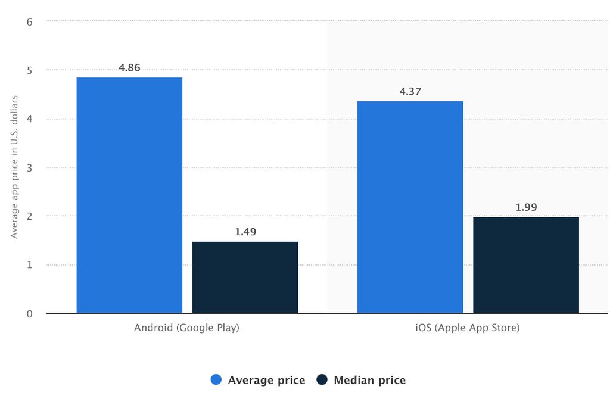

Figure 2: Abb. 4.1: Durchschnittlicher App-Preis

Quelle: statista, 2018

Spiele in App-Form für Tablet-Computer können in Zukunft eine größere Zielgruppe erreichen, da vermutlich solche Hardware noch häufiger als Spielkonsolen in den Haushalten vorhanden ist. Diese Geräte werden von den Erwachsenen (Primärnutzer) zumeist zu Zwecken des erweiterten Medienkonsum, also Zeitunglesen oder zum Videos schauen genutzt. Bei hochwertigeren Angeboten im Bereich Spiele-App werden auch Preise im niedrigen zweistelligen Bereich eingefordert. Diese Bepreisungen liegen allerdings weit unter den Verkaufspreisen für aktuelle Vollpreistitel für Spielkonsolen oder PC-Systeme. Diese Spiele schlagen mit durchschnittlich 36 € zu Buche. Auf der nachfolgenden Abbildung 4.2 ist in diesem Segment eine nahezu konstante Preisentwicklung zu sehen, die entsprechende Hardware, also die Spielkonsolen, welche benötigt werden, um diese Medien abzuspielen, weisen allerdings eine Preissteigerungstendenz auf. Dies steht im Gegensatz zu den sinkenden Kosten für Tablet-Computer.

Abb. 4.2: Durchschnittliche Spiele-Preise

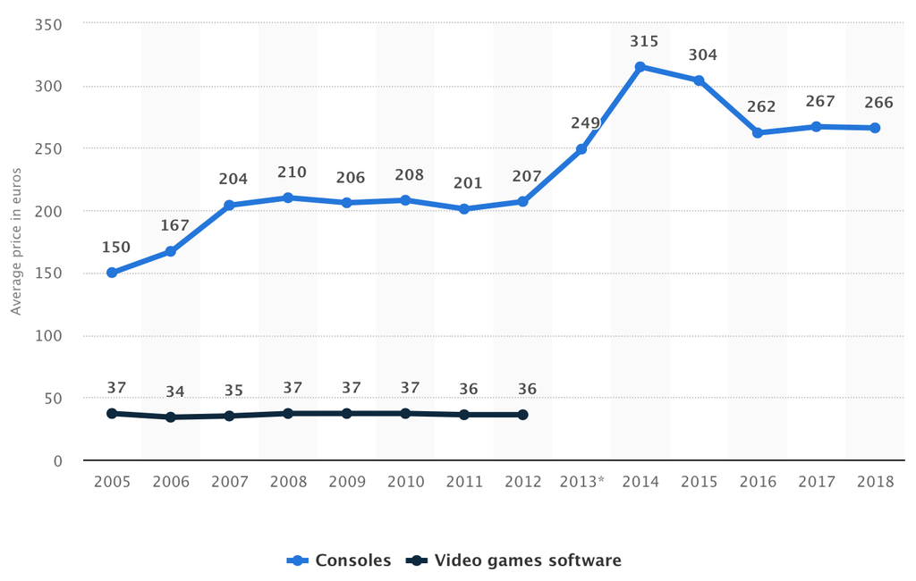

Figure 3: Abb. 4.2: Durchschnittliche Spiele-Preise

Quelle: statista, 2018

Nach Urlen (Urlen, 2017) sollen Kreativ-Apps für Kinder vorgezogen werden. Diese Apps mit pädagogischer Eignung, sollten dem Autor zufolge gemeinsam mit Freunden oder Eltern verwendet werden. Er verweist auf die Spiele-App-Datenbank des Deutschen Jugendinstituts, die insbesondere eine pädagogische Bewertung der Angebote ausschreibt. Holler (Holler, 2012) weist auf den Umstand hin, dass die Beurteilung der pädagogischen Eignung von Medien, also der ‚Gebrauchswert‘, aus Sicht der Kinder getätigt werden muss. Diese Perspektive ist einzunehmen, um nachvollziehen zu können, welche Einstellung ein Kind zu den Inhalten einnimmt und welche persönlichen Rückschlüsse ein Kind daraus für sich zieht. Auch konstatiert Holler, dass Kinder häufig aus den Unterhaltungsmedien bekannte Figuren kennen und diese automatisch positiv bewerten, um ihrer Peergroup anzugehören. Laut Urlen (Urlen, 2017) sind keine pauschalen Aussagen über den Schaden oder Nutzen für Kinder von App-Nutzung möglich, der Autor verweist an dieser Stelle darauf, dass die Medienkompetenzschulung im Rahmen der elterlichen Erziehung und des Vorlebens stattfinden sollte (Bundesjugendministerium, 2017).

Die WHO empfiehlt für Kinder unter zwei Jahren auf digitale Angebote zu verzichten. Nach ihrer Einschätzung sind 80 % der Minderjährigen zu wenig körperlich aktiv. Im Alter ab zwei Jahren, sollten Kinder nur unter der Betreuung der Eltern interaktive digitale Medien verwenden und diese sollten insgesamt auf kurze Dauer begrenzt sein. Die Forschung muss grundsätzlich noch klären, ab welcher Altersgruppe der Einsatz von digitalen Medien Vorteile bringen kann und mit welchen Inhalten und Spielmethoden Spiele versehen sein müssen, um keine nachteiligen Auswirkungen auf die Kinder zu haben. Wie ein Spiel auf seine Nutzer wirkt, ob der Spielende Freude daran hat und dauerhaft spielen wird, ist maßgeblich durch das Gamedesign bestimmt (Strahringer & Leyh, 2017). Zum Beispiel sollte auch das Verlieren bzw. Scheitern an einer Herausforderung Spaß machen oder anderweitig lohnenswert sein. Andernfalls bestünde Frustrationsgefahr des Spielers und er verlöre wohlmöglich die Lust am Weiterspielen. An dieser Stelle herrscht in der gängigen Forschung Ungewissheit, ob heutige Angebote mit ihrem Gamedesign die Entwicklung des Kindes optimal fördern.

Richtet man die Frage nach zukünftigen technologischen Innovationen direkt an die besagte Zielgruppe, wie in einer Studie der Telekom mit Zehn- bis Siebzehnjährigen, in deren Verlauf zukunftsorientierte Prototypen konstruiert wurden, kamen diese Kernaussagen zusammen: 1. Alles wird vernetzt sein, 2. Umgebungen werden intelligent, 3. Städte reagieren auf individuelle Bedürfnisse, 4. Roboter vereinfachen das Leben, 5. Digitale Kommunikation ist ins physische Leben eingebettet, 6. Virtual & Augmented Reality ist massentauglich, 7. Aktionen ersetzen klassische User Interfaces (UI), 8. Biometrische Daten ersetzen Passwörter, 9. Informationen werden vom Nutzer verwaltet und 10. Technologie wird neue Verhaltensweisen erzeugen (Von Reventlow & Thesen, 2019). Wie zuvor erwähnt, kann den sogenannten ‚Digital Natives‘, so wird die Generation, die von Klein an mit Mikrotechnologie aufgewachsen sind, genannt, eine natürliche und organische Neigung zu digitalen Erlebniswelten konstatiert werden. Um dieses Nutzungsverhalten und das veränderte Lebensumfeld von Kindern zu erfassen, fasst das Internationale Zentralinstitut für Jugend- und Bildungsfernsehen in einer jährlich erscheinenden Studie mit dem Titel ‚Grunddaten Kinder und Medien‘ dazu erhobene Daten zusammen. In dieser Studie geht hervor, dass Kinder auf dem Tablet-Computer zu allermeist Spiele spielen, dicht gefolgt von der Nutzung des Internets. Kinder spielen zu 75 % zumindest selten auf ihrem Tablet, in dieser Gruppe jedoch häufiger regelmäßig oder oft. Die Smartphone-Nutzung bei Zehn- und Elfjährigen stieg von 2014 auf 2017 von 71 % auf 87 %, die Tablet-Nutzung in dieser Altersgruppe sogar von 39 % auf 61 % (IZI (Internationales Zentralinstitut für das Jugend- und Bildungsfernsehen), 2019). Diese Analyse schlägt sich insbesondere auch in der aktuellen Neuorientierung der Industrie hin zu dieser Zielgruppe und der entsprechenden Gerätegruppe (mobile Endgeräte) nieder.

Das übergeordnete Ziel der BenBox.org ist Edukation. Die Festlegung des Titel auf den Bereich der Gesundheitsförderung liegt insbesondere wirtschaftlichen Betrachtungen zu Grunde. Der Gesundheitsmarkt ist ein sehr wachstumsstarker Markt, bietet Förderungen durch die GKV und erfreut sich hoher Beliebtheitsgrade. Ein eHealth Produkt muss sich allerdings den Anfordernissen der Nutzer bzw. Patienten im Gesundheitsmarkt, sprich der Volksgesundheit stellen. Im Jahre 2015 gab es in den bekannten App-Stores über 100.000 Apps zu den Themen Gesundheit und Medizin (Strotbaum & Reiss, 2017). Nach Häckl (Häckl, 2010) wird dieser Markt bis zum Jahr 2020 durchschnittlich um 5 % pro Jahr steigen, die Telemedizin- und Homecare-Sparte sogar um 10 %. Einhergehend mit diesen Erhebungen rechnet die Europäische Kommission, dass der eHealth Markt in Europa, mit einem derzeitigen Anteil von ungefähr 2 % der Gesundheitsausgaben, fast halb so finanzstark wie der Pharmamarkt wird. Zahlreiche Aussagen von Experten im Gesundheitswesen (Leistungsanbieter, Kostenträger, Organisationen, Industrie) bestätigen diese Prognosen. So gaben nach Häckl (Häckl, 2010) in einer Studie 80 % der befragten Technologie-Anbieter an, dass in diesem Bereich ein Umsatzwachstum zu erwarten sei, 73 % der in der Studie befragten Leistungsanbieter sehen Deutschland im eHealth-Sektor als einen wichtigen Standort an. In der Gliederung der Europäischen Kommission ist folgende Aufteilung des Marktes zu finden:

1. Klinische Informationssysteme
2. Telemedizin und Homecare
3. Integrierte (regionale / nationale) Gesundheitsinformationsnetzwerke

4. Systeme zur Unterstützung des Gesundheitswesens (keine direkte klinische Anwendung, z.B. Gesundheitserziehung)

Das dieser Arbeit zu Grunde liegende Produkt ist somit der 4. Kategorie zuzuordnen.

**4.1 Serious Game in der Edukation (eLearning)**

Der bildende Ansatz des BenBox.org Serious Games enthält mit den Punkten ‚Edukation‘ und ‚Gesundheitsförderung‘ eine Zweigliederung. Die Edukation soll im Spielverlauf durch eine Auseinandersetzung mit Geschichts-, Religions- und Informationstechnologiewissenschaften stattfinden. Im Speziellen werden die Geschichts- und Religionsbezüge durch die Expansionspolitik des Römischen Reiches sowie der katholischen Kirche thematisiert. Das Kinder spielerisch nicht nur motorisch lernen, ist nach Spitzer (Spitzer, 2002) ein unbestrittener Fakt. Er konstatiert, dass im Vergleich zu anderen Arten, beim Menschen die Betonung auf dem (fit) Werden liegt, nicht so sehr auf dem ‚fit sein von Anfang an‘. Dies soll größere Potentiale im späteren Verlauf der Gehirnentwicklung bieten. So kann davon ausgegangen werden, dass auch ein Kind auf vielen verschiedenen Ebenen lernt und eine Limitierung einer App auf nur eine Lernebene (z.B. Motorik) nicht nötig, evtl. auch gar nicht sinnvoll ist. Die BenBox.org Erzählung knüpft an diese neurowissenschaftlichen Sachverhalte an und projiziert besagte Entwicklungspotentiale des menschlichen Gehirns auf die beiden Roboter des Spiels. Zuerst beginnt die Erzählung mit neuem Leben, in Form der Inbetriebnahme der Roboter. Diese stehen sinnbildlich für das Aufwachsen des Kindes und später auch für das eigentliche Menschwerden. Roboter werden von Kindern überwiegend positiv bewertet und üben häufig eine große Faszination auf diese Zielgruppe aus (Von Reventlow & Thesen, 2019). Am Anfang des Spieles steht der Körper im Vordergrund, also das dingliche Erleben, welches mittels motorischer Übungen erfahren wird. Eltern sind laut Daun (Daun, 2012) allein verantwortlich für die Entwicklung ihres Kindes, auch wenn sie die Verantwortung bei steigendem Alter ihres Kindes häufig aufteilen. Das komplexe Thema der Erziehung kann der Autorin nach, durch Hilfe von Fachleuten oder Angeboten unterstützt werden.

Im weiteren Spielverlauf der BenBox.org findet mehr und mehr eine Auseinandersetzung mit geistig-spirituellen Inhalten statt, im Spielgeschehen z.B. versinnbildlicht mit der Programmierung der Roboter. Nach dem Psychologen und Philosophen William James teilt sich der Mensch in ein körperliches, mentales und spirituelles Selbst. Neben den motorisch-koordinativen Inhalten wird im Spiel eben auch eine Betrachtung der spirituellen und kulturellen Belange des Menschen bzw. Kindes vollzogen. Nach Bourdieu (Bourdieu, 1983) gibt es ein kulturelles Kapital, mit dem der französische Soziologe das Wissen um Dinge wie Kunst, Kulturgüter und Geschichte meint. Kinder und Erwachsene, die in diesen Bereichen gebildet sind, erschließen sich häufig eine höhere (berufliche) Entwicklung (Martin-Niedecken & Mekler, 2018). Der Kritik nach dem übermäßigen Einsatz der digitalen Techniken widerspricht Krämer (Krämer, 2019) und weist auf die Wichtigkeit von formatierten Flächen hin. Die Philosophin an der Freien Universität Berlin gibt zu bedenken, dass alle Wissenschaften, technisch-architektonische Arbeiten und die gesellschaftliche Kommunikation undenkbar wären, ohne die Erfindung von Papier und Stift, heute abgelöst durch z.B. Tablet-Computer. Die Autorin verweist bei Nutzung digitaler Inhalte allerdings auf die Schrumpfung des Intervalls zwischen Lesen und Verstehen hin, dem ihrer Aussage zufolge das kritische Denken und die Einsicht entspringen. So auch Goldin und Kutarna (Goldin & Kutarna, 2016), die anmahnen, dass die Kommunikation mittels der modernen Medien nicht immer auf Fakten beruhe. Laut den Autoren soll das Schlüsselelement für die Renaissance, also der Zeit des großen Aufschwungs in Kunst, Kultur und Technik, maßgeblich der Buchdruck von Gutenberg gewesen sein. Bei der Betrachtung der neuen Technologien sprechen sie sogar von der zweiten Renaissance, in welcher sich die Menschheit zurzeit befindet. So kann das Medium Serious Game sicherlich als Wissensvermittler in der Altersgruppe Kinder und Jugendliche fungieren. Als Beispiel dieser Wissensvermittlung sei auf die Thematisierung der Reliquienverehrung im BenBox.org Prototypen verwiesen. Dieses Thema wird im Spiel zentral behandelt und dem Spieler erklärt, dass die Stadt Köln so zu Reichtum und Ansehen gelangt ist. Nach Legner (Legner, 1989) kann dieses Ritual als der Versuch angesehen werden, den Toten wieder lebendig zu machen. Durch Zurschaustellung und Anbetung von Gebeinen erreichten religiöse Menschen Linderung ihrer Leiden. Diese Tatsachen sollen den spielenden Kindern erklärt und veranschaulicht werden und seinem kulturellen Kapital als Wissen hinzugefügt werden. Da die menschliche Zivilisation maßgeblich von der Durchführung von religiösen Ritualen und Praktiken geprägt wurde, kann von einer gleichbleibend hohen Relevanz dieses Themas ausgegangen werden (Gugutzer & Staack, 2015). An den hohen Kirchenaustritten, insbesondere aufgrund von Skandalen, lässt sich jedoch der allgemeine Bedeutungsverlust der Kirche im 21. Jahrhundert erkennen. Das Meinungsforschungsinstitut Forsa ermittelte 2015 in einer Umfrage, dass 61 % der Deutschen Religion und Glaube keine oder nur noch eine geringe Bedeutung zu räumen. Im Spiel wird mittels der Themen Religion und Spiritualität, die im Alltag bei den meisten Familien keine Bedeutung mehr zu haben scheinen, das kulturelle Erbe der Menschheit in den Erzählstrang eingearbeitet und thematisiert. Dies geschieht nicht zuletzt auch wegen der erzählerischen und philosophischen Möglichkeiten, die diese Themen bieten.

Die Story spielt in einer Science-Fiction-Parallelwelt, was größte erzählerische Freiheiten gewährt und findet zum heutigen Zeitpunkt statt. Der Comic- und Erzählstil ist beschreibbar als eine Mischung aus der Nickelodeon (Privater Fernsehsender für Kinder) Kindersendung ‚The Rugrats‘ und dem Sci-Fi-Comic ‚Futurama‘ von Matt Groening (Erfinder der Simpsons-Serie). Der Storyverlauf setzt seinen Fokus auf die Spätantike und Frühes Mittelalter mit dem Schwerpunkt auf der Romanik, dem Römischen Reich sowie der katholischen Kirche und führt die Spieler in Außeneinsätzen auf der ‚Via Sacra‘ überwiegend in solche historischen Bauwerke. Die Romanik ist die erste ganz Europa umfassende Epoche mittelalterlicher Kunst und in Köln augenscheinlich durch die ‚Via Sacra‘ mit den zwölf Groß-Romanischen Kirchen als christliche Sakralkunst zu begreifen (Toman, 1996). Somit kann das Spiel mit dem Dom als Identifikationsobjekt, gerade im Kölner, aber auch deutschsprachigen Raum, auf eine hohe Wiedererkennungsrate hoffen. Die BenBox.org Geschichte ist als ein pseudo-wissenschaftlicher Geschichts- und Religionsdiskurs zu verstehen und soll den Kindern Gedankenanstöße insbesondere zu religiösen, spirituellen und philosophischen Themen geben. Was unter diesen Begriffen im Rahmen dieser Arbeit zu verstehen ist, soll zuvor in kompakter Weise definiert werden. Religion steht in der BenBox.org Erzählung für die Auseinandersetzung mit dem Unbegreiflichen, dem was man nicht wissen kann oder darf. Außerdem stand die Religion immer unter der Deutungshoheit der katholischen Kirche, was sich z.B. in den christlichen Dogmen ersehen lässt. Religion bekommt heutzutage daher den Anstrich des Althergebrachten, des Verstaubten und scheint geradezu nicht mehr mit der Moderne zu vereinbaren zu sein (Lay, 1995). Der Spieler wird häufig in Kirchen geführt und erfährt dort vielfältiges historisches und religiöses Wissen. Dort gerät er in unmittelbare Gefahr als er den ‚Kleaner‘ Robotern begegnet und wird somit mit der eigenen Sterblichkeit konfrontiert. Dieses unausweichliche Ende der menschlichen Existenz wird in Form der Reliquien greifbar gemacht. Da gerade der Tod schon immer der Deutungshoheit der Kirche oblag, wird dieses Thema im Spiel durch den Blick der Religion betrachtet und diskutiert und wenn nötig, werden die Erklärungsmodelle der kirchlichen Dogmen verworfen. Der Begriff Spiritualität hat nach Bucher (Bucher, 2014) den Umhang des Mittelalters abgelegt und wird heutzutage quasi inflationär benutzt. Er beschreibt im Spiel das Immaterielle, steht sowohl auch für das Phantastische und wird gleichzeitig bei den inhaltlichen Bezügen zur Mythologie verwendet. Demgegenüber steht die philosophische Auseinandersetzung für die wertfreie Betrachtung eben solcher Sachverhalte, worin die BenBox.org Erzählung sich verpflichtet fühlt.

Die BenBox.org Science-Fiction-Story wird den Kindern außerdem IT-Begriffe und Kenntnisse in einfacher und plastischer Weise erläutern. Die Sachverhalte werden im Schwerpunkt Technologien sein, mit denen die Kinder in Zukunft in Berührung kommen werden, allerdings auch gegenwärtige IT-Produkte. Eine nicht abschließende Aufzählung von IT Begriffen, vorrangführt von dem BenBox.org Spielelement, das diese Technologie verkörpert: ‚BenBox‘ ≙ Starke KI, ‚SAM‘ und ‚SEB‘ ≙ Roboter, ‚STRIX‘ ≙ Updates und die ‚BenBox Protokolle‘ ≙ Datenschutz. Die IT-Landschaft wird immer komplexer und kann von einem einzelnen kaum noch überschaut werden. Assistenz-Systeme wie Google Assistent, Siri (Apple) und Alexa (Amazon) versprechen daher Erleichterung im Alltag und bündeln in geschlossenen System die verfügbaren Funktionen. Gerade der Konsum, also der Kauf von Produkten, steht im Vordergrund. In Unternehmen erlauben programmierte Chat Bots eine Optimierung der Geschäftsprozesse. Daten werden verschlüsselt in der Cloud gespeichert, der Gesundheitsmarkt z.B. erfordert den verstärkten Einsatz von Sicherheits- und Datenschutztechnologien, um Daten zu erfassen, zu speichern und zu verarbeiten. Deep Learning Technologien vermögen es sogar, Aufgaben, die im Grunde für den Menschen leicht sind, für ein Computersystem jedoch schwer zugänglich, da nicht durch mathematische Formeln berechenbar, Muster zu erkennen, wie z.B. Sprache oder Gesichter (Nvidia, n.d.). Daraus kann in Zukunft eine starke KI entstehen, sobald sie verschiedene Lösungsansätze gegeneinander abwiegen kann. Im Spiel werden die erwähnten Begriffe und Sachverhalte aufgegriffen und dem Spieler in interaktiver und symbolischer Form präsentiert. Der zunehmenden Bedeutung von KI, wird im Spiel durch die BenBox im Mittelpunkt Rechnung getragen. Die bildliche, linguistische und interaktive Erfahrung des Spielers lässt hoffen, dass für ihn ein nachhaltiges Lernen ermöglicht wird und aus pädagogischer Sicht eine adäquate Vorbereitung auf die technologische Zukunft stattfindet.

**4.2 Serious Game in der Gesundheitsförderung (eHealth)**

Der Aspekt der Gesundheitsförderung des BenBox.org Serious Games umfasst theoretische wie praktische Elemente. Wie im Einleitungsteil dieser Arbeit formuliert, ist das Ziel von Angeboten im Genre Exergames das Embodiment. Vereinfacht ausgedrückt kann dieser Begriff, welcher aus der kognitiven Verhaltensforschung stammt, mit Bewusstsein in Beziehung zum eigenem Körper verstanden werden. Diesen Ansatz machen sich die somatopädagogischen Disziplinen zunutze und verwenden Techniken, die den Schüler in die Lage versetzen, mehr aus seiner Körperlichkeit abzuleiten, als er es sonst im hektischen Alltag zu leisten vermag. Nach Steinmüller, Schaefer und Fortwängler (Steinmüller et al., 2009) erfordert das Abwegen von Handlungsoptionen, wie zuvor bei der Entwicklung einer starken KI beschrieben, im menschlichen Gehirn eine inhibitorische Leistung. Andernfalls muss auf den ersten Reiz automatisiert reagiert werden und ineffiziente Bewegungsmuster können das Ergebnis sein. Kindern im Grundschulalter lastet zudem nicht selten ein unnatürlicher Sitzzwang sprichwörtlich auf den ‚Schultern‘, ob ein ergonomischer Schulranzen mit digitalen Büchern, sogenannten eBooks (versprechen Gewichtsreduktion), dem krummen Rücken Einhalt gebieten kann, mag zu bezweifeln sein. Aus diesen Gründen werden im Spielverlauf vom Spieler real-motorische Auseinandersetzung mit der ihn umgebenden räumlichen Dimension abverlangt. ‚SAM‘ und ‚SEB‘, die beiden Spielercharaktere, sind ganz wie im Kindesalter aufgefordert, die einfachsten motorischen Übungen zu absolvieren. Im Spielverlauf werden diese Aufgaben im ‚Holo Deck‘ gezeigt und die Punkte vom jeweils anderen Spieler vergeben. Diese Übungen werden immer fordernder und komplexer, die Kinder machen diese motorischen Interventionen zum Teil mit Hilfsmitteln wie einem Balance Board und Gegenständen wie einem Holzschwert und Schirm. Die gewonnen Punkte werden im ‚Updater‘ vom Spieler durch die schwache KI ‚STRIX‘ vergeben und auf die Fähigkeiten Beweglichkeit, Geschmeidigkeit und Gleichgewicht verteilt. Diese Fähigkeiten werden dem Kind im Spielverlauf erläutert und die Bezüge zum eigenen Körper aufgewiesen.

Nach Sinclair, Hingston und Masek (Sinclair et al., 2009) und ihrer DualFlow Theorie, muss ein solches Exergame die Balance zwischen spielbasierter Herausforderung und der Spielerfähigkeit, sowie der Komplexität der geforderten Bewegung und dem motorischen Fähigkeiten des Anwenders herstellen. Nur dann wird ein immersives Erlebnis, sprich eine Vertiefung in die virtuelle Welt stattfinden. Da die moderne Sensorik von Unterhaltungsspielemedien kaum eine adäquate Bewertung von Ganzkörperbewegungsmustern nach therapeutischen Gesichtspunkten erlaubt, beginnen Deep-Learning-Ansätze unter größten Mitteleinsatz momentan gerade erst Mimik zu erkennen, wird das BenBox.org Spiel zu zweit gespielt. An den entsprechenden Stellen im Spiel wird ein Kind aufgefordert eine Übung durchzuführen, während der Mitspieler diese einschätzen soll. Hierbei wird strikt auf eine neutrale und humanistische Bewertungsweise geachtet. Nach Daun (Daun, 2012) liegen im Lob bzw. der Kritik große Potentiale der Einflussnahme, aus pädagogischer Perspektive jedoch auch in eine nachteilige Richtung. Frau Daun beschreibt das Loben, wenn damit vom Lehrer gewünschtes Verhalten gezielt aufgewertet wird, als emotionalen Aufladungstrick. Das führt auf der neurobiologischen Ebene zu einer vermehrten Dopamin Produktion beim Kind und nicht wie beim von Csikszentmihalyi beschriebenen ‚Flow‘, zu einer Noradrenalin und Serotonin Ausschüttung im Gehirn. Das Kind kann nach Daun so seine natürliche Lernlust verlieren, wie in Abb. 4.2.1 schematisch skizziert.

Abb. 4.2.1: Angeborene Lernlust

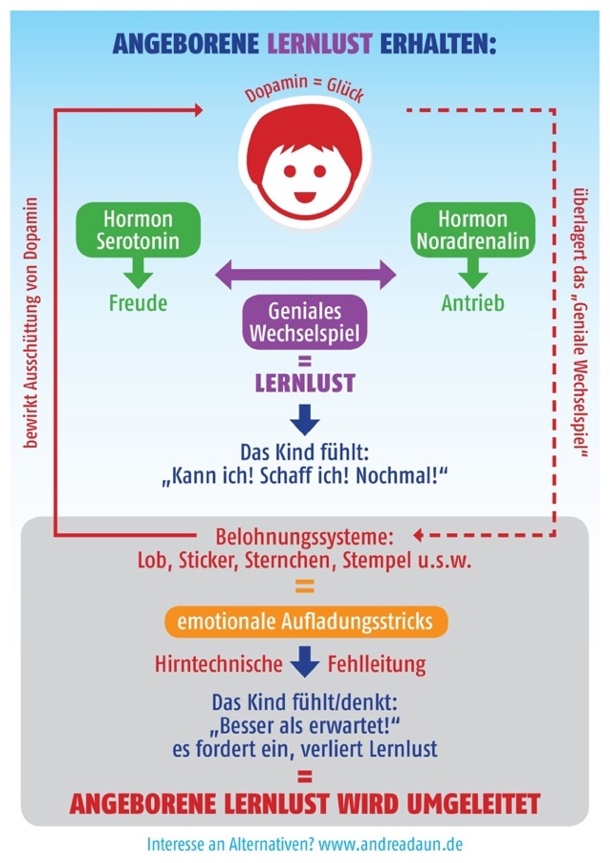

Figure 4: Abb. 4.2.1: Angeborene Lernlust

Quelle: Andrea Daun, 2012

Letztendlich können die Transmittersysteme des Gehirns nicht isoliert betrachtet werden, da nach aktuellen Erkenntnissen nie völlig unabhängige Funktionen der Teilsysteme zu beobachten sind (Förstl, 2012). Daher ist die Aussage, dass nach Gaschler (Gaschler, 2019) Jugendliche am stärksten auf Lob reagieren an dieser Stelle bedeutsamer, als welche Transmittersysteme an diesem Prozess beteiligt sind. Gaschler räumt der Phase der Adoleszenz, präzise dem Alter von zehn bis neunzehn Jahren, die ständige Verbesserung der Fähigkeiten Selbstbeherrschung und Introspektion zu, gepaart allerdings mit Sensationslust, starker Orientierung an den Gleichaltrigen und Risikobereitschaft. Im Besonderen ist der Peer-Effekt ein Merkmal dieses Alters. Folglich kann davon ausgegangen werden, dass die gegenseitige Bewertung gruppentypisches Verhalten positiv bewertet und anders herum, untypisches Verhalten schlechter. Dem gegenüber steht, gerade da häufig das Emotionssystem meist vor dem Präfrontalkortex ausgereift ist, die leidenschaftliche und kreative Auseinandersetzung mit Problemen. Die jungen Menschen sind bereit altanerkannte Strategien beiseite zu legen, um neuen Ansätzen zu folgen oder diese zu initiieren. Gerade diesen Umstand, das Erkunden von neuen Lösungsstrategien, möchte die BenBox.org durch die Bewertung der Mitspieler belohnt, gefördert und wertgeschätzt wissen. Im Wirtschaftsleben und im eHealth-Sektor wird diese Eigenschaft und entsprechende Technologien Disruption genannt (Strotbaum & Reiss, 2017). Ein Begriff der gehäuft im Zusammenhang mit den neuen digitalen Medien verwendet wird.

Soll eine derartige disruptive Applikation bzw. eine die disruptives Verhalten fördert erfolgreich vermarktet werden, muss zusammenfassend gesagt werden, dass der Spieler ein forderndes, aber auch lohnendes Erlebnis erfahren muss. Daraus leitet sich ab, dass der Anwender eine persönliche Erweiterung der eigenen Fähigkeiten erfährt. Eine Verwendung von Gamification (Lob) im Sinne der Kundenbindung und Erweiterung des Absatzes muss den Mitteln der bestmöglichen Entwicklung des Kindes nach geordnet sein. Nur so kann der Ansatz dem Anspruch genügen ‚pädagogisch wertvoll‘ zu sein. Resümierend soll dieser Anspruch bedeuten, dem Kind kulturelles Wissen, Religiosität und Philosophie nahe zu bringen und die Souveränität im Umgang mit sich und der Welt zu fördern. Ein zu diesem pädagogischen Modell fast gegensätzlich stehender Ansatz ist in der klassischen Werbung zu finden. Diese bedient sich Beobachtungen, wie der Mensch auf bestimmte Situationen emotional reagiert. Häufig entstammen diese Erkenntnisse der (klinischen) Psychologie. Als Beispiel wird ein In-App-Kauf angenommen. Dieser Kauf bedeutet einen geringen Involvement vom Nutzer und wird durch die primär emotionale Reaktion, die als eine Art Vorentscheidung zuvor stattfindet, ausgelöst. Die sich erst anschließende sekundäre, sachliche Bewertung, muss sich alsdann bei einem Kleinstbetragkauf im Falle der Negativbewertung über eine starke Emotion hinwegsetzen (Kroeber-Riel & Esch, 2015). Erfahrungsgemäß zeigen Kinder, man stelle sich eine Mutter mit Kind an der Kasse eines Supermarktes vor, an welcher Süßigkeiten, Spielkarten und dergleichen dargeboten werden, hier wenig rationales Verhalten. Die Mutter spiegelt in diesem Falle die rationale Bewertung dar.

Schwerpunkt des Produktes soll nicht allein auf der motorischen Lernebene liegen, dann könnte man von einem klassischen Exergame sprechen, von denen vielfältige Ausprägungen am Markt verfügbar sind. Das Spiel soll vielmehr ein Produkt der allgemeinen Gesundheitsförderung und Persönlichkeitsentwicklung sein. Nach Förstl (Förstl, 2012) umfasst die Entwicklung des menschlichen Gehirns sowohl bio-psychische als auch spirituelle Dimensionen. Letztere sind ein wesentlicher Bestandteil menschlichen Erlebens, ist er doch ein narratives Wesen, das seine Lebensgeschichte tagtäglich neuschreibt und im Kontext seiner aktuellen persönlichen Wahrheit und Weltsicht immer wieder umdefiniert. Nicht zuletzt dient das spirituelle Selbst der effektiven Auseinandersetzung mit Krisen und Traumata. Gerade Traumata sind insbesondere in den Bewegungs- und Haltungsmustern von Menschen abgebildet (Steinmüller et al., 2009). Somatopädagogische Methoden erlauben neben der Diagnose eben auch die therapeutische Intervention zur Lösung dies gearteter Blockaden. Zuerst muss jedoch die Notwendigkeit einer Veränderung erkannt und somit die Sinnhaftigkeit von ganzheitlicher Heilung anerkannt werden. Die BenBox.org Erzählung deckt zu diesem Zwecke einen Teil der geschichtlichen Tragödien in symbolischer und kindgerechter Form auf. So soll dem Spieler ein Bewusstsein geschaffen werden, dass er Teil einer transgenerationalen Geschichte ist. Auf diese Weise kann das Kind Bezüge zur heutigen Gesellschaft mit ihren unterschiedlichen Befindlichkeiten und Bedürfnissen aufstellen.

Da das Raumschiff in der Erzählung, es ist ein liegender Korpus, an den menschlichen Körper erinnert, können neben motorisch-erzieherischen Inhalten auch medizinische Zusammenhänge spielerisch bearbeitet werden. Im ‚Maschinenraum‘ treibt quasi ein Herz das Sternenschiff an und erlaubt damit Vergleiche zum Herz-Kreislaufsystem, so die Gänge des Schiffes wie Blutgefäße des menschlichen Körpers anmuten. Infolgedessen entsteht im Spielverlauf regelmäßig der Auftrag, die Systeme der ‚Pulp‘ (engl. Fleisch), so heißt das Raumschiff, auf dem die Crew in das irdische Sonnensystem gereist ist, zu reparieren, auf die Geschichte übertragen also zu heilen. Diese Heilung findet indes auch im Betriebssystem des Schiffes, sprich in der Programmierung statt. Im BenBox.org Erzählstrang haben die Vorbesitzer des Schiffes an diesem Modifikationen vorgenommen, was eine De-Programmierung von Nöten macht. Diese und weitere Spielgeschehnisse finden im ‚Hangar‘ statt, wo auch die ‚BenBox‘ (KI) anzufinden ist. Mittels der KI kann die Übertragung vom Schiffs-Betriebssystem zum menschlichen Gehirn vollzogen werden und den Kindern so die komplexe menschliche Neurobiologie vereinfacht erläutert werden. In Feldenkrais (somatopädagogische Methode) ist hier auch von Reorganisation im Sinne der ‚sensorischen Integration‘ die Rede, an welcher insbesondere die somatomotorische Rinde des Großhirnes beteiligt ist. Der Bezug zur menschlichen Motorik wird an dieser Stelle ebenso vollzogen. Nach Schellhammer (Schellhammer, 2002) übernimmt diese Schaltzentrale im Großhirn funktionale Aufgaben wie die Propriozeption (Tiefenwahrnehmung). Diese motorischen Kerne, in denen komplexe Bewegungsprogramme geplant und angebahnt werden können, sind dem Hirnstamm übergeordnet. Phylogenetisch ist das propriozeptive System am jüngsten, weist dadurch weniger stark ausgeprägte Kontakte zu den anderen Systemen auf. Aufgrund der immer größer werdenden Extremitäten des Menschen, welche der Hirnstamm, wegen der wachsenden Ansteuerungskomplexität, nicht mehr in der Lage war zu steuern, entwickelten sich Regionen im Großhirn die diese Aufgaben übernahmen (Schellhammer, 2002). Auf die Motorik bezogen, spricht man an dieser Stelle von kinästhetischer Differenzierungsfähigkeit. Differenziert werden muss zwischen Kraft, Zeit und Raum. Die Kinästhetische Differenzierungsfähigkeit ist eine wesentliche Komponente in der modernen Rückenschule (Flothow et al., 2011). Insbesondere die Methode der Alexander-Technik, mit ihrem Kernthema ‚Bewusste Steuerung‘, ist dazu geeignet den Schüler darin zu schulen, mittels Hemmung von Reaktionsmustern (Inhibition), Bewegungsmuster effizienter zu gestalten, in dem muskuläre Verspannungen gelöst werden (Gaschler, 2019; Steinmüller et al., 2009). So kann dieses gewichtige Thema der menschlichen Motorik spielerisch auf der theoretischen und praktischen Ebene vermittelt werden und gilt als Schwerpunkt des BenBox.org Exergames.

**4.3 Ökonomische Betrachtungen eines Serious Games**

Der Prototyp wurde von Kindern zwischen acht und neun Jahren gespielt. Die Zielgruppe soll erweitert auf die Altersgruppe von Sechs- bis Dreizehnjährige angesetzt werden. Nach Pyka (Pyka, 2017) sind junge Menschen für das Marketing eine sehr sinnvolle Zielgruppe. Es gab 2014 laut einem Bericht des Bevölkerungsfonds der Vereinten Nationen (UNPFA) rund 1,8 Milliarden Menschen im Alter von 10 bis 24, so viele wie nie zuvor in der Menschheitsgeschichte, und ihre Zahl soll weiter steigen. Nach Strotbaum und Reiß (Strotbaum & Reiss, 2017) können gerade spielerische und motivierende Ansätze, sprich Serious Games und Anwendungen mit Gamificationelementen, im Präventionsbereich vielversprechend vermarktet werden. Die Autoren konstatieren eine Hinwendung von bestehenden IT Unternehmen im Gesundheitsmarkt zu diesem Thema, sowie Gründungen von Start-Ups in diesem Bereich. Nun soll im Speziellen geprüft werden, ob ein Serious Game ökonomisch Erfolg versprechend sein kann und wenn ja, unter welchen Bedingungen dieser Erfolg erreicht werden kann. Um mit einer Unternehmung erfolgreich zu sein, muss zuerst ein Produkt konzeptioniert sein, um anschließend die Zielgruppe klar einzugrenzen. Nach Greiner, Schulenburg & Vauth (Greiner et al., 2008) ist eine Unternehmung im Gesundheitsbereich in zwei Teile zu spalten - den Leistungsbereich und den Finanzbereich. An der Wertschöpfung sind, wie im folgenden Schaubild (Abb. 4.3.1) zu sehen, die Input Faktoren, die Erstellung, die Verwertung und der Output beteiligt.

Abb. 4.3.1: Produktion von Gesundheitsprodukten

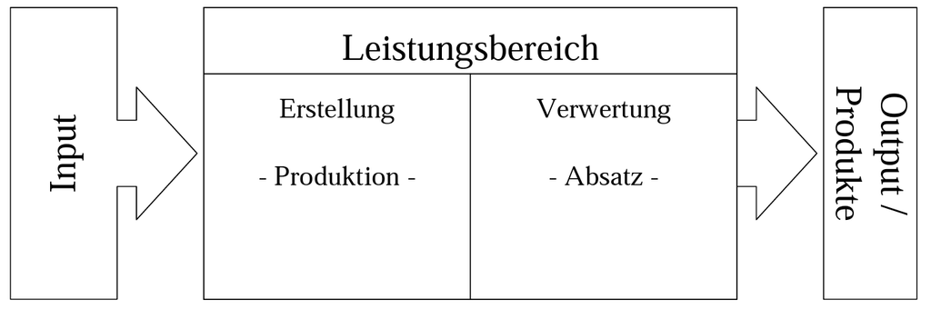

Figure 5: Abb. 4.3.1: Produktion von Gesundheitsprodukten

Quelle: Greiner, Schulenburg & Vauth, 2008

Die Input Faktoren sind die Fähigkeiten des Entwicklers, sein spezifisches Gesundheitswissen und die Fähigkeit kreative Anwendungen zu konzeptionieren. Die Erstellung findet beim vorgestellten Produkt hauptsächlich digital statt. Dazu wird ein Computer verwendet, um die Programmierung durchzuführen, sowie um die grafischen Medien zu erstellen. Hinzu kommen Auftragsarbeiten von zwei Zeichnerinnen. Als fertiges Produkt (Output) entsteht der BenBen.org Prototyp.

Nun gilt es zu klären, welche Finanzierungs- und Vertriebswege für die BenBox.org am sinnvollsten sind. Laut Strotbaum und Reiß (Strotbaum & Reiss, 2017) muss medizinische Expertise mit Kompetenz in der Softwaregestaltung verbunden werden. Beispiele wie Freeletics zeigen, dass ein Unternehmen diese Expertisen durch Mitarbeitergenerierung auch hinzuholen kann, um erfolgreich zu sein kann. Die drei Gründer verkauften 2018 ihre Anteile an der besagten Fitness-App in hoher zweistelliger Millionenhöhe, obwohl die drei Betriebswirte über keinerlei medizinische Ausbildung verfügten, geschweige denn Informatiker waren (Tischer, 2018). Ob dieses Unternehmensmodell für die Anforderungen von qualitativen eHealth-Lösungen am besten geeignet ist, soll an dieser Stelle nicht der eingehenden Betrachtung unterzogen werden. Vielmehr soll aufgezeigt werden, dass innovative digitale Produkte und nicht zuletzt Ansätze mit unterhaltenden Charakter (Games, Serious Games etc.), im wachsenden Markt große finanzielle Erfolge erreichen können. Dies sieht mittlerweile auch die Bundesregierung so und veranschlagt 50 Millionen Euro für das erste Jahr als Förderung von Spieleentwicklungen in Deutschland. Dieses Geld soll im Bundeshaushalt 2019 freigegeben werden und zur Förderung von Prototyp- und Produktion-Entwicklungen mit einer Summe zwischen 30.000 bis 400.000 € ausgeschrieben sein (game - Verband der deutschen Games-Branche, 2018). Auch Google, mit dem dazugehörigen Mutterkonzern Alphabet, plant seine Bestrebungen im Computer-Spiele-Markt auszubauen. Im Herbst diesen Jahres wird der eigene Spiele-Streaming-Dienst Stadia erscheinen. Auf den Servern von Google werden moderne Spiele gerendert und als interaktiver Inhalt auf die Rechner der Kunden gestreamt. Stadia visiert einen großen Markt an Gelegenheitsspielern an, denen die Anschaffung von spielefähiger Hardware (Spielkonsolen und PC) zu teuer ist. Diese Zielgruppe kann mit Googles Streaming-Dienst, per monatlicher Zahlung von 10 €, Zugang zu vielen verschiedenen Spielen bekommen, wenngleich Vollpreis-Spiele noch zusätzlich durch Einmalzahlungen erworben werden müssen (Herbig, 2019). Der Vorteil ist, dass das Streaming von aufwendigen grafischen Szenen vom Nutzer keine spezielle Hardware erfordert und somit auch auf Rechnern in Schulen und Firmen zu Verfügung steht. Einzig die Internetanbindung muss ein performanter Breitbandanschluss sein. Die Game-Engine Unity, mit der viele hochwertige Spiele auch als Crossplattform-Lösung entwickelt werden, ermöglicht die kostengünstige zeitgleiche Entwicklung für mehrere Zielsysteme (PC, Konsole, mobile Endgeräte etc.). Unity wird zum Start von Stadia diese Streaming-Technologie von Google unterstützen. Auch unterstützt die Game-Engine die Verwendung von VR-Brillen und ist mit allen am Markt gängigen Technologien (HTC Vive, Oculus Rift etc.) kompatibel und bereit auch diesen Wachstumsmarkt mit Angeboten zu adressieren.

**4.3.1 Vertriebswege**

Im Bereich der App-Spiele, die über App-Stores vertrieben werden, hat sich mit Mikrotransaktionen oder In-App-Käufen eine neue Monetarisierungsform etabliert. Diese versprechen große Einkünfte für den Hersteller, da eine stetige Einnahmequelle generiert wird und nicht, wie bei konventionellen Festpreistiteln üblich, nur eine einmalige Gewinnausschüttung beim Kauf. Die In-App-Käufe bescheren dem Spieler neue Spielinhalte, häufig sind das Spielgegenstände, die das Erreichen des Spielzieles vereinfachen. 2016 legte der Verkauf dieser virtuellen Güter um 17 % zu, auf insgesamt 659 Millionen Euro im Bereich der Free-to-Play Spiele, bei denen der Hersteller nur durch diese Zusatzangebote Geld verdient, da das Spiel grundsätzlich umsonst ist. Monatliche Investitionen der Nutzer sind auf 13,57 € gestiegen (game - Verband der deutschen Games-Branche, 2017). Clash Royale, ein kostenloses Handy- und Tablet-Spiel, konnte in den ersten zweieinhalb Jahren über zwei Milliarden Euro umsetzen. Dazu verwenden die Hersteller Machine-Learning-Technologien, mit denen die In-App-Angebote maßgeschneidert für den einzelnen Spieler angepriesen werden (Heim, 2018). Auch Anbieter von klassischen Brettspielen reagieren auf die Entwicklungen und verfolgen, durch die zusätzliche Implementation einer Handy- oder Tablet-App in das Spielgeschehen, in einigen ihrer Angebote einen hybriden Spielansatz. Nach Niebert (Niebert, 2018) sind diese Apps teils kostenlos, teils kostenpflichtig und generieren zusätzliche Spielinhalte, speichern den Spielstand und helfen bei der Auswertung. Auch Apps, die die Spielregeln erklären sind am Markt verfügbar. Ob diese zusätzlichen digitalen Applikationen zudem In-App-Kauf-Funktionen implementierten haben, muss im Einzelfall geprüft werden.

Eine klassische Einnahmequelle für digitale Medien ist die Schaltung von Werbung für Produkte von anderen Herstellern. Sogenannte ‚Rich-Media‘ Formate zeigen komplexe Banner, auf denen Video, Audio sowie interaktive Inhalte zu sehen und hören sind. Da die Klickrate (auf einen Werbebanner) im Schnitt nur 0,09 % entspricht, muss ein Werbetreibender herausstechen, um seine Zielgruppe ohne Streuverluste zu erreichen (Lammenett, 2014). Ein Anbieter der Werbefläche verkauft, profitiert je nach Abrechnungssystem von erfolgreich vermarkteter Werbung seines Kunden, sollte diese also gezielt einsetzen und dem Kunden gegenüber seine Zielgruppe und deren Bedürfnisse detailliert beschreiben können. Für ein Serious Game für Kinder sollte die Werbung also z.B. Spielzeug, aber auch weitere digitale Angebote wie kindgerechte Spiele und Videos enthalten. Somit kann ein Spieleanbieter auch ohne In-App-Verkaufssystem Umsatz generieren. Der Entwickler Part Time Monkey Oy verzeichnete für das Spiel Breakout Ninja, nachdem Apple das Spiel in der Kategorie ‚neues Lieblingsspiel‘ ausgezeichnet hatte, mehr als 650.000 Downloads. Part Time Monkey Oy nahm in dieser Zeit jedoch nur etwa 1.000 € durch den In-App-Kauf zum Deaktivieren der Werbung ein, in einer Woche jedoch rund 21.500 € für Werbung (Schneider, 2017). Apple verdient aus In-App-Käufen generierten Zahlungen zu 30 % des Umsatzes mit. Diese Regelung trifft auch große Software-Anbieter, wie zum Beispiel Microsoft mit ihren Office-Programmen, die ihre Programme über den Apple App-Store verbreiten (Günther, 2014). Viele Spieleentwickler nehmen in ihren aktuellen Angeboten jedoch Abstand von Mikrotransaktionen und Werbung, weil sie grundsätzlich auf den Nutzer abschreckend wirken und verwenden wieder Fixpreise für ihre Produkte (Beineke, 2019). Unter iOS (iPhone und iPad-Geräte) lässt sich die In-App-Kauf-Funktion über die Einstellung ‚Bildschirmzeit‘, zum Schutz von Kindern, auch komplett deaktivieren, damit kein unbeabsichtigter Kauf mehr stattfinden kann. Zu denken gibt allerdings die Integration dieser Option an besagter Stelle im Mobile-Betriebssystem von Apple, da die Rubrik ‚App-Store‘ ebenso in den Einstellungen hinterlegt ist und diese Funktion dort sinngemäß zu erwarten wäre. Auch ist die Deaktivierung von In-App-Käufen unter ‚Bildschirmzeit‘ nur möglich, wenn die Funktion aktiviert wird. Dies legt die Vermutung nahe, dass Apple den Verlust von Einnahmen dadurch zu kompensieren versucht, mehr Nutzer- bzw. Nutzungsdaten zu gewinnen. Becker (Becker, 2019) zufolge versucht Apple sich von seinen Mitbewerbern (Microsoft, Google etc.) abzusetzen, indem sie insbesondere die Datenschutz- und Privatsphäre-Ansprüche ihrer Nutzer respektieren und dementsprechend Funktionen in ihre Produkte integrieren. Das Unternehmen aus Cupertino in Kalifornien liefert im eigenen Apple App-Store für Eltern einen detaillierten Leitfaden zu diesen Themen und beschreibt dort die verfügbaren Schutzfunktionen für Kinder. Hier muss allerdings grundsätzlich zwischen geschicktem Marketing und unternehmerischer Realität unterschieden werden, wie das gezeigte Beispiel von Apple aufzeigt. Laut Statista wurde 2011 mit diesen unterschiedlichen Strategien pro Games-App-Nutzer auf dem Apple Betriebssystem iOS im Durchschnitt ein Umsatz von 4 US-Dollar pro Monat erzielt.

**4.3.2 Finanzierungsstrategien**

Der ‚Calliope mini‘, ein Mini-Computer mit dem Schüler ab der dritten Klasse Programmieren lernen und ein Verständnis von Mikrotechnologie bekommen, wird in vielen Schulen in Rahmen von Pilotprojekten eingeführt, bisher finanziert durch Crowdfunding. In den einzelnen Bundesländern haben Stiftungen zusätzlich Gelder zur Schulung des Personals bereitgestellt. In Zukunft möchte die Calliope gGmbH die ‚Calliope mini Boards‘, sowie die benötigten Schulungen, durch die einzelnen Länder finanziert bekommen. Diese Finanzierungen würden im Rahmen der Digitalisierungsstrategien der verschiedenen Landesregierungen ermöglicht. Die Krankenkassen wiederum entwickeln eigene Medizinprodukte oder fördern innovative eHealth Applikationen von IT Unternehmen oder Start-Ups. Die Versicherten können dann diese Apps und Spiele zu vergünstigten Konditionen oder im Rahmen der Gesundheitsförderungen der jeweiligen GKVs nutzen.

Abb. 4.3.2.1: Budgetplan ‚Bolt Riley Episode 1‘

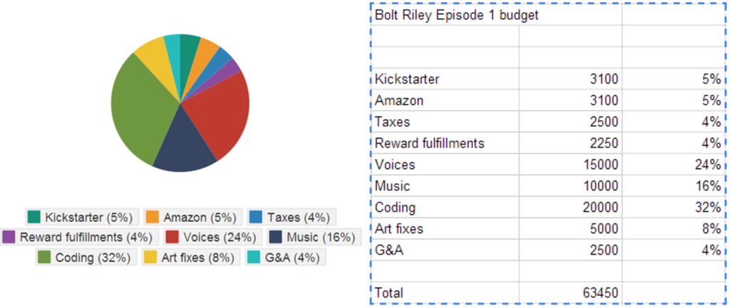

Figure 6: Abb. 4.3.2.1: Budgetplan ‚Bolt Riley Episode 1‘

Quelle: Kickstarter.com, 2019

In einer Crowdfunding-Kampagne werden häufig Meilensteine eingerichtet, nach deren Erreichen bestimmte Funktionen des Spieles implementiert werden. Dies erhöht zum einen den Anreiz zur Investition für potentielle Käufer, andererseits kann ein Spiel auch trotz nicht vollständigem Erreichen einer Investitionssumme entwickelt werden. Weitere bekannte Modelle der Finanzierung sind die Einnahme von Risikokapital durch Investoren, welche im Gegenzug Unternehmensanteile erwerben (Perridon et al., 2016). Außerdem haben einige bekannte Spieleentwickler durch Vorverkaufseinnahmen ihre Entwicklungen erst ermöglichen können. Das Spiel wird bei Release dann häufig vorab an diese Käufer vergeben, was für einige Fans des Produktes einen eindeutigen Mehrwert zu bedeuten scheint.

**4.3.3 Vertriebs-, Finanzierungs- und Marketingmix**

Der Hersteller Game Workshop hat zusammen mit dem Entwicklungsstudio Play Fusion für das Spiel ‚Warhammer Age of Sigmar: Champions‘ eine geteilte Vermarktungsstrategie gewählt. Game Workshop verkauft zu ihrem Free-to-Play Titel neben den üblichen In-App-Käufen, zusätzlich gedruckte Sammelkarten, mit denen der Spieler neue Inhalte und Erweiterungen freischalten kann. Diese Kartensets sollen Online zu kaufen sein, in sogenannten Onlineshops. Die Warhammer-Reihe umfasst viele verschiedene Arten von Spielen, analoge sowie digitale und besitzt eine weltweite Fangemeinde. So konnten die Entwickler in zehn Tagen nach Einführung eines der sogenannten ‚Booster Packs‘ fast zehn Millionen Karten verkaufen (PRNewswire, 2018). Das dazu gehörige digitale Handy-Spiel wird in den großen App-Stores, Google Play (Android Geräte) und Apple Store (iPhones und iPads) angeboten. Das BenBox.org Spiel für Tablet-Computer kann auf unterschiedliche Weise vertrieben, finanziert und beworben werden. Diese sollen nun in Kürze beschrieben werden um anschließend eine Entscheidung bezüglich der besten Vermarktungsstrategie zu treffen.

Vertrieb:

- Festpreis-Vermarktung und Vertrieb durch Publisher oder App-Stores
- Free-to-Play Vermarktung mit In-App-Käufen über App-Stores
- Free-to-Play Vermarktung mit Werbung über App-Stores
- Free-to-Play Vermarktung über App-Stores mit Käufen von Spielkarten über eine Onlinehandel-Plattform
- Vertrieb an Schulen mittels Länderfinanzierung
- Vertrieb in Kooperation mit einer GKV und gleichzeitiger Bezuschussung

Finanzierung:

- Eigenkapitalfinanzierung durch den Hersteller
- Fremdkapitalfinanzierung durch Banken
- Risikokapital durch Investoren
- Vorverkaufs-Finanzierung durch Privatinvestoren
- Crowdfunding-Finanzierung durch Privatinvestoren
- Fördergelder durch z.B. den Bundeshaushalt

Marketing (nach Schön):

- Aussagekräftige Beschreibung des Produktes (Schlagwörter verwenden)
- Erstellen und senden von Trailer und Werbevideo (innovative Spielinhalte)
- Werbung in Foren (Entwickler-, Fan- und Spieleforen)
- Bewertung der App durch Nutzer (Anfragen stellen an Testportale)
- Werbung in sozialen Netzwerken (Facebook, Instagram, Twitter etc.)

(Schön, 2013)

- Werbung auf Webseite einer GKV

Wie in den zuvor beschriebenen Entwicklungen gezeigt, können diese Strategien miteinander kombiniert werden, um so eine geteilte Vertriebs-, Finanzierungs- und Marketingstrategie zu betreiben.

**4.4 Ökonomische Betrachtungen eines Corporate Games**

Nach dieser eingehenden Betrachtung der Finanzierung und Vermarktung von Serious Games, soll in Kürze, im Hinblick auf eine Übertragung des Spielansatzes auf eine erwachsene Zielgruppe, eine mögliche Strategie für ein Corporate Game besprochen werden. Für eine erwachsene Zielgruppe gelten andere Regeln, sowohl für Design und das UI eines Spieles, aber insbesondere auch für dessen Vermarktung. Erwachsene Anwender können im Gegensatz zu Kindern In-App-Käufe tätigen, da sie voll geschäftsfähig sind. Bei einem Corporate Game kann also für ein Angebot mit diesem Monetarisierungsansatz gearbeitet werden. Ob zusätzlich Werbung geschaltet wird, sei zu prüfen. Darüber hinaus kann die Applikation einen festen Preis haben, bzw. ein Abo-Modell nutzen. Zur Monetarisierung kann zusätzlich der Präventionsleitfaden herangezogen werden, um eine geldliche Entlastung für die Nutzer zu erwirken. Die Primärprävention nach §20 SGB V bietet Anbietern von präventiven Gesundheitskursen die Möglichkeit, sich zertifizieren zu lassen. Die Zentrale Prüfstelle für Prävention (ZPP) organisiert dazu versicherungsübergreifend die Präventionsangebote der GKVs. Unter der Rubrik IKT (Informations- und Kommunikationstechnologie-basierte) sind auch digitale Kurse einzureichen. Zu den für Anbieter zertifizierbaren Kursen zählen ‚Blended Learning‘, ‚Onlinekurse‘, ‚Fernkurse‘, ‚Gesundheitscoaching für Gruppen‘, ‚Game based learning / Serious Games / e-Teaching‘ oder ‚Telefoncoaching‘. Wird ein IKT Kurs von der ZPP nach §20 Präventionsleitfaden zertifiziert, kann der Kursteilnehmer bei erfolgreicher Teilnahme die Kosten anteilig, häufig 75 bis 150 € pro Kurs, erstattet bekommen. Diese Förderung würde auch für minderjährige Versicherte gelten, diese werden unter der Bezeichnung Familienversicherte in den Mitgliederregistern der Gesetzlichen Krankenkassen geführt. Die Erwachsene Zielgruppe wird oftmals durch die Bewerbung der Kurse auf den Webseiten der Krankenkassen erreicht. Diese übermitteln automatisiert, aus den Datenbeständen der ZPP, die Kursdaten auf ihre eigenen Webportale. Außerdem kann ein Anbieter von digitalen Präventionsangeboten jede Form der verteilten Print-, Online- und Sozial-Media-Werbung schalten, sowie lokale Werbeflächen nutzen.

# 5 Ergebnisse

Von 22 Kindern der Klasse haben 15 an der Umfrage, deren Teilnahme freiwillig war, teilgenommen. Das entspricht einer Teilnahmequote von knapp 70 %. Somit ist n = 15. Die Gruppe bestand aus acht Mädchen und sieben Jungen. Der Altersschnitt lag bei Studiendurchführung bei 8,4 Jahren. Im ‚Item 1‘ (Abb. 5.1) wurde die Beliebtheit der Protagonisten erfragt. Hier ist ersichtlich, dass die ‚BenBox‘ die höchste Beliebtheit aufweist. Damit hat der Namensgeber des Spiels zu 100 % der abgegebenen Stimmen mit der besten Bewertung ‚Super‘ erhalten. An zweiter Stelle befindet sich ‚SAM‘ mit elf Stimmen (73 %), dicht gefolgt von ‚SEB‘ mit zehn Stimmen (67 %). Die Protagonistin ‚Emmi‘ bekam in der Kategorie ‚Ganz ok‘ mit sechs die häufigste Stimmenanzahl, was 40 % der abgegebenen Stimmen entspricht.

Abb. 5.1: Item 1

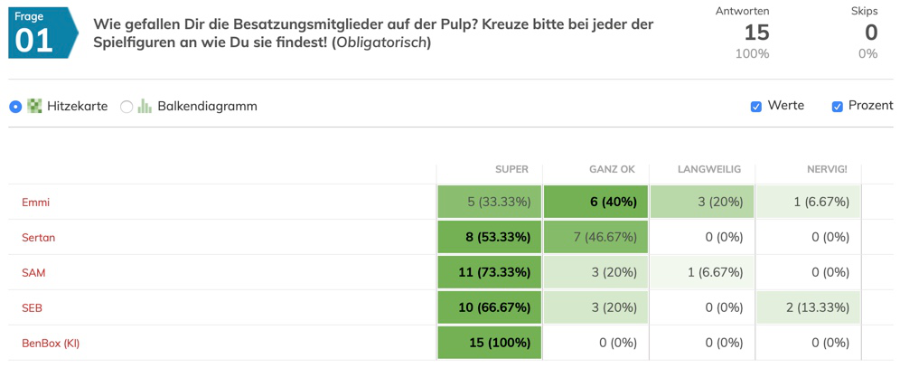

Figure 7: Abb. 5.1: Item 1

Quelle: Eigene Datenerhebung

Das ‚Item 2‘ (Abb. 5.2) zielte auf die Kaufgewohnheiten der Schüler ab. Die Kinder sollten angeben, wofür sie ihr Taschengeld ausgeben. Sticker und Sammelkarten wurde von neun Kindern angegeben, das waren 28 % der abgegebenen Stimmen. Da eine Mehrfachauswahl möglich war, entspricht dies 60 % der Kinder. Süßigkeiten und dergleichen, sowie digitale Spiele wurden achtmal bzw. von 53 % der Kinder ausgewählt.

Abb. 5.2: Item 2

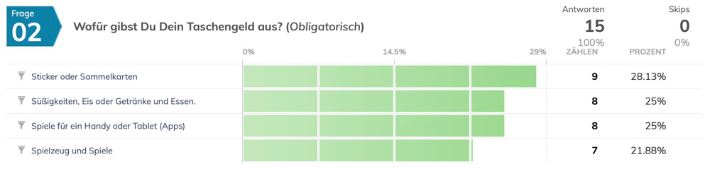

Figure 8: Abb. 5.2: Item 2

Quelle: Eigene Datenerhebung

Die Frage nach der Spielform in ‚Item 3‘ (Abb. 5.3) beantworteten zehn Kinder mit der höchsten Wertung. Das entspricht ⅔ der Spieler. Weitere vier Kinder fanden diese Art von Spiele ‚Ganz gut‘, ein Kind selektierte die Antwortkategorie ‚Blöd‘.

Abb. 5.3: Item 3

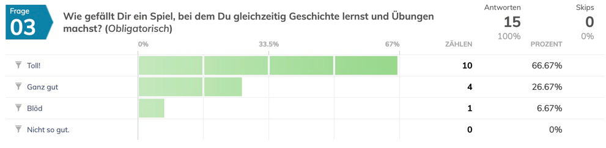

Figure 9: Abb. 5.3: Item 3

Quelle: Eigene Datenerhebung

Die Frage nach dem Spannungsgrat (‚Item 4‘) der Geschichte (Abb. 5.4), sowie dem Humor, zielte auf die erzählerische Darbietung ab. ‚Ja, ich finde die Geschichte toll!‘ konnte mit 14 Stimmen 93 % erreichen. Nur eine Wertung mit der Kategorie ‚Die Geschichte ist nicht so gut‘.

Abb. 5.4: Item 4

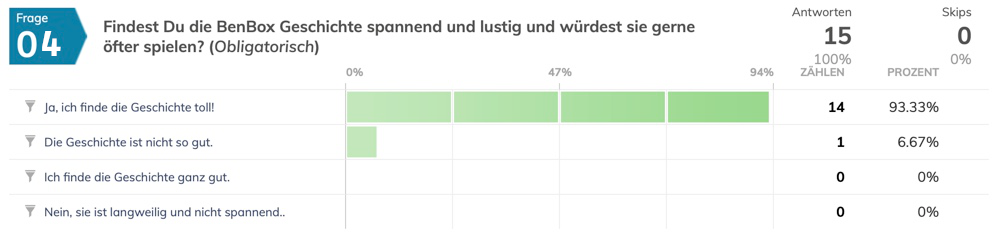

Figure 10: Abb. 5.4: Item 4

Quelle: Eigene Datenerhebung

Schlussendlich wurde in der Umfrage im ‚Item 5‘ (Abb. 5.5) erfragt, ob das Kind bereit wäre Taschengeld für das Spiel auszugeben und wenn ja wieviel. Die höchste Häufigkeit hatte die Kategorie ‚10 Euro‘ mit acht abgegebenen Stimmen. Fünf Kinder stimmten für ‚5 Euro‘ ab. Im arithmetischen Mittel bedeutet das einen Wert von 7 €.

Abb. 5.5: Item 5

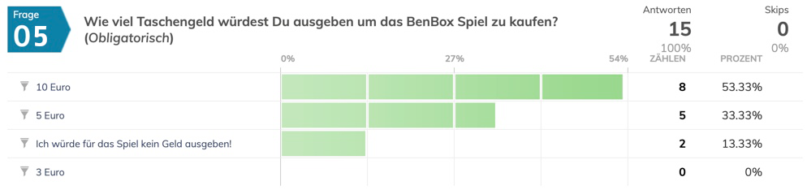

Figure 11: Abb. 5.5: Item 5

Quelle: Eigene Datenerhebung

Im Durchschnitt wurden von den Kindern am Ende des Spieles beim finalen Punktestand 2,1 Karten abgegeben. Im Weiteren wurde erhoben, wie die Paarungen die Spielkarten eintauschten. Daraus ergab sich folgender Datensatz:

Paarung (Prg) 1: 3 und 3 Karten; Prg 2: 1 und 1 Karten; Prg 3: 2 und 1 Karten; Prg 4: 3 und 3 Karten; Prg 5: 0 und 0 Karten; Prg 6: 3 und 3 Karten; Prg 7: 3 und 3 Karten; Prg 8: 3 Karten (zweiter Spieler ohne Wertung da eine Betreuerperson).

Somit trafen sechs von sieben Paarungen die gleiche Entscheidung bezüglich der Ausgabe der Spielkarten. Das entspricht einer Häufigkeit von 86 % identischer Endscheidung.

# 6 Diskussion

Die BenBox.org Unternehmung muss einen ökonomischen Nutzen ausweisen, sprich ein effizientes Vertriebssystem beinhalten, Finanzierungssicherheit vorweisen, um die Entwicklungskosten zu tragen, sowie ein zielgruppenorientiertes Marketing aufweisen. Mit einem Monetarisierungskonzept in dem mittels In-App-Käufe Geld eingenommen wird, kann bei Kindern aus zwei Gründen nicht gearbeitet werden. Erstens verfügt die Zielgruppe durch ihre eingeschränkte Geschäftsfähigkeit nicht über einen entsprechenden zahlungsfähigen Zugang zu den Vertriebskanälen App-Stores (Google und Apple), zweitens kann diese Zielgruppe aus pädagogischen und medizinischen Gründen nicht über die eigenen Gesundheitsausgaben entscheiden.

In der Altersgruppe ist indes eine erhöhte gruppendynamische Komponente zu identifizieren, was auch die Ergebnisse der fast immer gleichen Spielkartenabgaben am Spielende nahelegt. Dieser Aspekt kindertypischen Verhaltens soll im vorgestellten Produkt in keiner Weise die zu treffenden Entscheidungen über Gesundheitsvorsorge beeinflussen. An dieser Stelle kann von mindestens zwei unterschiedlichen Betrachtungen ausgegangen werden. Zum einen ist ein starker Gemeinschaftssinn positiv für die sozialen Fähigkeiten eines Kindes, eine Gruppenzwangsituation zum anderen eher als hinderlich im Individualisierungsprozess des Kindes zu verstehen. Wenngleich die Antworten der Kinder in der Studie grundsätzlich als ehrlich, also ohne Hintergedanken oder Umfrage steuernde Absichten gemacht wurden, kann ein Kind in dieser Altersgruppe sicherlich nicht als allein verantwortlich bezüglich der eigenen Gesundheit und Entwicklung gelten. Somit muss das BenBox.org Marketing einen Fokus auf den Wert der Gesundheit legen und die Reduzierung von Gesundheitskosten versprechen. Dieses Argument soll zu allererst an die Krankenkassen adressiert werden.

Einen zweiten Fokus wird auf die Entwicklung und Ausbildung des Kindes gerichtet sein. Dass die digitalen Medien nicht mehr aus dem Leben von Kindern wegzudenken sind, ist ein nicht zu bestreitender Fakt. Vielfältiger individueller Nutzen, Unterhaltung, kommunikatorische Vernetzung und die Verknüpfung vormals verteilter Daten sind der Nutzen den ein Kind daraus ziehen kann. Lag die Verantwortung über die Unterstützung des Kindes in seinem Aufwachsen zuvor fast ausschließlich bei den Eltern und Lehrern, kann diese nun aufgeteilt werden. Dies können auch digitale Anwendungen leisten, allerdings nur sofern die Sicherheit der Angebote garantiert ist.

Als dritter Fokus, gilt es die eigentliche Zielgruppe Kinder, durch ein spannendes und herausforderndes Spiel, zu erreichen. Aus den Umfrageergebnissen geht hervor, dass das Prototyp-Produkt eine für Kinder angemessene Bild- und Textsprache verwendet hat. Außerdem konnten die eingesetzten Protagonisten die Zielgruppe ansprechen, sowie zum Projizieren (Erwartungen) und Identifizieren (Selbstreflexion) anregen. Das belegen die Umfrage ‚Items 1‘ und ‚Item 4‘ in der Studie. Einzig und allein die Protagonistin ‚Emmi‘ mit durchschnittlichen Bewertungen, muss überdacht und evtl. neu konzipiert werden. Notwendigerweise braucht die Geschichte eine vernünftige bzw. erwachsene Person, was zu einer solchen Bewertung durch Kinder führen kann. Da einige Grafiken des Spieles teilweise in frühen Entwurfszuständen implementiert wurden, um Fristen einzuhalten und die Kosten für den Prototypen zu senken, kann für ein produktionsreifes Produkt auch insgesamt von einer höheren Qualität ausgegangen werden. Ein Serious Game für Gesundheit ist bei Kindern, einer Zielgruppe, die grundsätzlich lernfreudig ist, ‚Item 3‘ der Umfrage kann diese Forschungshypothese bestätigen, ein wachendes Spielegenre und verspricht Marktanteile. In der Umfrage gaben die Kinder an, im Schnitt 7 € ihres Taschengeldes investieren zu wollen. Diese Zahl spricht für die Eigenmotivation der Zielgruppe dieses Angebot zu nutzen. Allerdings kann ein durchschnittlicher App-Preis von ca. 4 € für die BenBox.org nicht angesetzt werden. Auch der durchschnittliche Preis für Vollpreis-Titel von ca. 40 € soll nicht veranschlagt werden. Die Mehrwerte, Hinzuwachs des gesundheitlichen und kulturellen Kapitals, müssen den Entscheidern (Krankenkassen und Eltern) beim Kontakt mit dem Produkt allgegenwärtig sein. Das Ziel der Unternehmung ist es somit, einen Kauf des BenBox.org Spieles seitens der Eltern zu generieren, die dieses Angebot über die Webseite der Krankenkasse offeriert bekommen, niemals jedoch dem Kind alleine eine Kaufentscheidung zuzubilligen.

Als Kalkulationsgrundlage für die Preisgestaltung des Angebotes dient die angestrebte Kooperation mit der TK und die Bewerbung der BenBox.org über die ‚www.tk.de‘ Webseite. Von den 2,5 Millionen Familienversicherten sind schätzungsweise 20 % also 500.000 der Altersgruppe 6 bis 13 Jahre zuzuordnen. Daraus ergibt sich bei einer anvisierten Marktdurchdringung von 5 % eine zu erwartende Zielgruppengröße von ca. 25.000 Nutzern. Im Hinblick auf die reinen Entwicklungskosten, es wird eine Summe von 150.000 € kalkuliert, bedeutet dies Umlagekosten von 6 € pro Nutzer. Dazu kommen Marketingkosten und diverse weitere Aufwendungen wie die Unterhaltung einer Geschäftsstelle von insgesamt 50.000 €. So kann von einer Umlage von zusätzlichen 2 € pro verkauften Artikel gerechnet werden. Die Produktionskosten setzen sich aus den Kostenstellen der Tabelle 6.1 zusammen:

Abb. 6.1: Tabelle - Produktionskosten

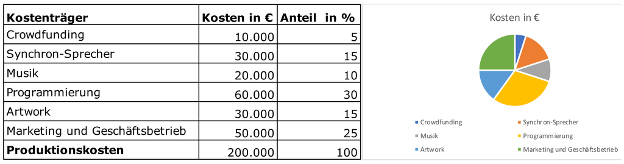

Figure 12: Abb. 6.1: Tabelle - Produktionskosten

Quelle: eigene Darstellung

Die Grenzkosten des Produktes sind sehr gering, da bei einem digitalen Produkt keine weiteren Materialien zum Einsatz kommen müssen und nur der Vertriebsweg (anteilige Umsatzausschüttung) und Geschäftsbetrieb Kosten verursachen. Daraus ergibt sich eine maximale Skalierbarkeit des Produktes von Seiten der Produktion. Eine Kooperation mit einer Privaten Krankenkasse (PKV) kann somit eine gute Perspektive sein, um weitere Nutzer zu gewinnen. Diese Zusammenarbeit sollte keine Probleme seitens der bestehenden Partnerschaft mit der TK mit sich bringen, da zwischen den beiden Krankenkassen keine direkte Mitbewerberschaft besteht. Die gesamten Produktionskosten (Tab. 6.2) von 200.000 € sollen mittels dieser Kapitalquellen erschlossen werden:

Abb. 6.2: Tabelle - Kapitalquellen

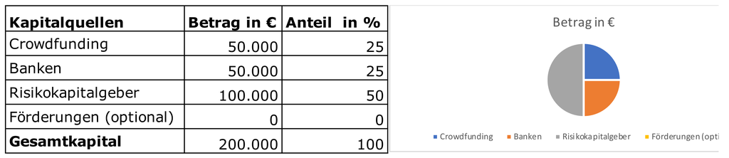

Figure 13: Abb. 6.2: Tabelle - Kapitalquellen

Quelle: eigene Darstellung

Fiele eine dieser Kapitalquellen aus, soll zuerst mittels Förderungen am Finanzplan festgehalten werden, bevor Kosteneinsparungen diskutiert werden.

Durch die Kooperation mit der Krankenkasse soll eine Zielgruppe von mindestens 25.000 potentiellen Versicherten, Kinder im Alter von 6 bis 13 Jahren, erreicht werden. Die Vertriebsstrategie soll zweiteilig sein:

- Zum einen kann das Spiel über die Mitgliedschaft der Gesetzlichen Versicherung subventioniert erworben werden, es ist dementsprechend kein Free-to-Play Titel. Der Kaufpreis soll mit 99 € angesetzt werden, was das empfohlene Taschengeldniveau eines Kindes im Alter von 6 bis 13 deutlich übersteigt (Nissen, o. J.). Die jeweilige Krankenkasse bezuschusst allerdings bei regelmäßiger Teilnahme abschließend den Präventions-Kurs mit 75 € und dem Käufer entsteht somit nur eine geringe finanzielle Belastung. Es ist anzunehmen, dass eine Rückenschule, welche als Serious Game digital, also vernetzt zu nutzen ist, gegenüber den Sportangeboten in dieser Altersklasse einen besseren Stand hat, als eine reguläre lokal und terminiert stattfindende Kinderrückenschule. Deren Verbreitungs- und damit Bekanntheitsgrad ist grundsätzlich deutlich unter denen der Rückenschulen für Erwachsene anzunehmen. Letztendlich müssen die Entscheider, die Eltern, überzeugt werden, um diesen im Vergleich zum klassischen Spielemarkt deutlich höheren Verkaufspreis erzielen zu können. Der Hinweis, dass es sich um eine Gesundheitsdienstleistung handelt, muss also zwingend erbracht werden. Durch die Verknüpfung von Spiel und Gesundheitsprophylaxe, soll eine entsprechende maximale Nutzungszeit, orientiert an der typischen Kursdauer eines Offline-Kursangebotes, eingerichtet werden. Dies ist auch im Hinblick auf die Medienkompetenz der Kinder anzustreben.
- Der Zweite Vertriebsansatz soll die Möglichkeit sein, Erweiterungen anzubieten. Die Erweiterungen des BenBox.org Spieles, in Form von neuen Übungen und Inhalten, geschieht nicht durch klassische In-App-Käufe, sondern durch den Erwerb von Spielkarten. Diese Spielkarten sind über einen Online-Shop zu erwerben und mit handelsüblichen Bezahlmethoden wie Überweisung, Rechnung, PayPal und dergleichen zu bezahlen. Mit den Spielkarten kann das Kind anschließend auch außerhalb der digitalen Spielumgebung spielen, sowie Zusatzinhalte im Serious Game freischalten. Hier ist von einer Hybridisierung zu sprechen, wie sie einige Spieleanbieter zuvor betrieben haben.

Der Kauf wird nur volljährigen Personen angeboten, also Personen deren Medienkompetenz und Mündigkeit als ausreichend ausgebildet anzunehmen ist. Die BenBox.org verfolgt demnach eine Monetarisierungsstrategie, bei der die Bezahlmechanismen von den Eltern bzw. den Erziehungsberechtigten ausgelöst werden müssen. Dementsprechend muss sich das Marketing auf die Eltern konzentrieren. Um das Produkt jedoch bei einer der Gesetzlichen Krankenkassen platzieren zu können, muss der Mehrwert der entsprechenden Versicherung schlüssig dargestellt werden. Hier ist das entscheidende Mittel, auf die Kosten von Gesundheit eines Kindes hinzuweisen. Es ist nicht anzuraten, profitorientierten Unternehmen wie Apple, Google und vergleichbare im Schutz von Minderjährigen voll zu vertrauen, unabhängig davon, wie umfangreich diese Technologieanbieter die Schutzfunktionen in ihren Produkten implementiert haben und diese bewerben.

Dass ein solches Angebot innerhalb des üblichen Vermarktungsweges über einen App-Store erfolgreich vertrieben werden kann, ist zu bezweifeln. Zum einen verlangen der ‚Google Play-Store‘ und ‚Apple App-Store‘ hohe Umsatzbeteiligungen, was zu einer Schmälerung des Gewinnes führen würde, zum anderen, ist der Verkaufspreis ungleich höher als der der Konkurrenzprodukte. Allenfalls können die App-Stores der Bereitstellung des Produktes (Download) dienen, jedoch nicht der Monetarisierung über die dort gängige Bezahlinfrastruktur.

# 7 Fazit und Ausblick

Ob das beschriebene Serious Game ohne eHealth-Kooperationspartner (GKV) in den App-Stores gegen das große Angebot an Spiele-Apps mit In-App-Kauf Funktion und Werbung bestehen kann, bleibt zu klären. Apps ohne In-App-Kauf Funktion generieren den App-Store-Anbietern keine Umsätze, genauso wie jene die auf Werbeeinblendungen verzichten. Dies könnte sich negativ auf das Ranking im jeweiligen App-Store auswirken.

Über den Vertriebsweg des Kartenverkaufes, ist ebenso denkbar eine Private Krankenkasse, die üblicherweise keine Subventionierungen zu Präventionsdienstleistungen ausschüttet, als Kooperationspartner zu gewinnen. In diesem Fall muss der Verkaufspreis von 99 € gesenkt werden, um eine breite Nutzergruppe anzusprechen. Dahingehend, dass eine klar umschriebene Zielgruppe definiert wurde, sollte diese PKV sinnvoller Weise eine passende Mitgliederstruktur ausweisen. Der bisher als Prototyp entwickelte eHealth Ansatz soll dazu weiterentwickelt werden. Schlussendlich soll die BenBox.org eine PI werden und dem Nutzer aufzeigen, wie er sich am besten bzw. am schnellsten weiterentwickeln kann. Dieses Assistenz-System soll allerdings nie autonome Entscheidungen für die Kinder treffen, sondern allenfalls den Stellenwert einer Entscheidungshilfe innehaben. Weiterhin werden neue Programmfunktionen benötigt, um die Spiel- und Lerninhalte besser und variantenreicher vermitteln zu können. Diese Erweiterungen können nur durch den Zukauf von externen Programmierern realisiert werden bzw. der Rekrutierung von Mitarbeitern mit entsprechenden Fähigkeiten. Da Darmstadt eine hoch angesehene Hochschule im Informatiksektor aufzuweisen hat, kann der Bedarf an Fachkräften dort gestillt. Als kostengünstige Alternative könnten Programmierer aus dem Projekt der Digital School of Integration (kurz: ReDi), welche in München und Berlin Schulen betreibt, könnten für diese Zwecke akquiriert werden. ReDi schult Flüchtlinge aus Krisengebieten im Programmieren. Die Entwicklung der BenBox.org soll Cross-Plattform erfolgen. Das heißt, es sollen verschiedene Versionen für die beiden wichtigen mobilen Betriebssysteme, Android und iOS, entwickelt werden. Dieser Schritt kann kosteneffizient mit der Game-Engine Unity erfolgen (Thomas, 2018). Stadia kann ein zusätzlicher Vertriebskanal sein, der einen erweiterten großen Absatzmarkt von Gelegenheitsspielern erschließt und aufgrund des Abo-Systems eine stetige Einnahmequelle bedeuteten würde. Es steht außerdem in Planung, die neue Darstellungsform der Virtual Reality zu implementieren. Dazu würde die BenBox.org als BenBox.VR in Zukunft neuaufgelegt werden. Die BenBox.VR würde dann die Zielgruppe Erwachsene erschließen, als ein Corporate Game. In Kooperation mit der Hochschule Darmstadt und Prof. Philipp Thesen, der im Studiengang Industriedesign im Fachbereich Gestaltung die Mensch-System-Interaktion erforscht, soll ab Oktober 2019 dazu in Zusammenarbeit ein Prototyp der BenBox.VR entstehen. Mit diesen technischen Voraussetzungen könnte eine PI motorisch sinnvolle Bewegungen auf die VR-Brille projizieren, damit der Nutzer neue Bewegungsstrategien und komplexe Koordinationsleistungen ausprobieren und einstudieren kann. Durch die Erweiterung der Produktpalette mit dem BenBox.VR Corporate Game, wäre eine Diversifizierung erreicht und gleichzeitig verschiedene Absatzmärkte anvisiert.

Das BenBox.org Spiel soll zum Teil durch Risikokapitalgeber, also mit Geld von Investoren, finanziert werden. Um diese zu überzeugen, Kapital in das Projekt zu investieren, soll ein sogenanntes Pitch Deck erstellt werden, mit dem an speziellen Investoren-Veranstaltungen für das Produkt geworben werden soll. Die Vorstellung des BenBox.org Prototypen erlaubt die visuelle Präsentation des zukünftigen Produktes, was eine mögliche Akquirierung von Investoren grundsätzlich erleichtert würde. Dazu würde im Anschluss an diese Arbeit ein Businessplan erstellt, welcher einen fundierten Finanzplan enthalten würde. Die Firma neuland.digital GmbH, geführt von dem in Köln ansässigen Unternehmer Karl-Heinz Land, berät Unternehmen in der digitalen Transformation und unterstützt Start-Ups mit ihrem Netzwerk an Investoren. Neuland.digital GmbH soll für die beiden Projekte Risikokapital einsammeln und darüber hinaus in der Rolle des Publisher fungieren, um die termingerechte Produktion zu managen. Im Anschluss an die Finanzierungsphase soll mit der Mitarbeitersuche begonnen werden, um ein Team an tatkräftigen und innovativen Fachkräften für die Umsetzung der BenBox.org und BenBox.VR zu akquirieren. Das für diese Zwecke gegründete Unternehmen soll ‚Serious Ben Entertainment‘ heißen und langfristig den zuvor beschriebenen ökonomischen Nutzen erbringen. Das Unternehmen soll als GmbH geführt werden. Durch die gute Reputation dieser Unternehmensform soll das noch fehlende Kapital von einer Bank eingezogen werden. Außerdem soll parallel geprüft werden, ob eine Förderung in Anspruch genommen werden kann. Fördermittel, zum Beispiel die Games-Förderung der Bundesregierung, können helfen die Finanzierbarkeit dieser zusätzlichen Funktionen zu gewährleisten. Eine zusätzliche Kapitalquelle soll durch eine Crowdfunding-Kampagne erschlossen werden. Es hat sich gerade im Computer-Spiele-Markt gezeigt, dass sich hier große Mengen an Fremdkapital durch Privatinvestoren erschließen lassen und durch die Verwendung von Meilensteinen die Wahrscheinlichkeit einer Produktion erhöhen lässt. Die Privatunterstützer sollen als Ausgleich dafür Merchandise Artikel und andere Honorierungen bekommen, die je nach Höhe der finanziellen Unterstützung ausgeschüttet würden.

Um im Vorfeld die Bekanntheit des innovativen Projektes zu steigern, sowie um am starken Digital-Health-Cluster Netzwerk in der Region Köln-Bonn zu partizipieren, soll die BenBox.org im Rahmen des Health-i Award 2019 in der Kategorie ‚Junge Talente‘ am Wettbewerb mit Einsendeschluss am 12. Juni diesen Jahres teilnehmen.

# Anhang

**Spielgrafik 1:** ‚SAM‘ und ‚SEB‘

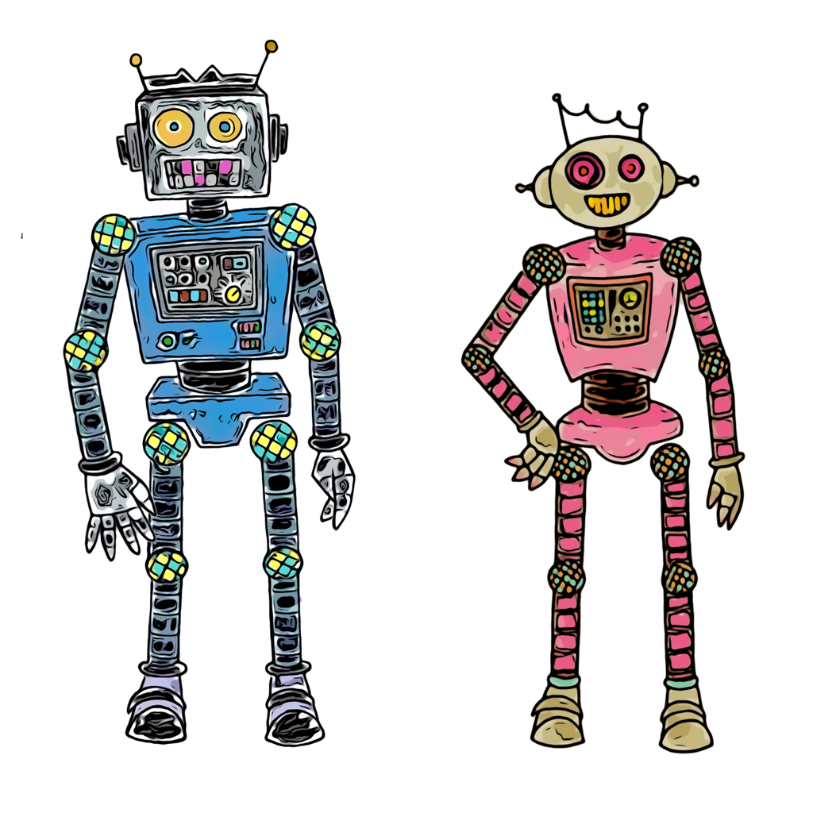

Spielgrafik 1: ‚SAM‘ und ‚SEB‘

**Spielgrafik 2:** ‚Pulp‘

[figure not shown]

Spielgrafik 2: ‚Pulp‘

**Spielgrafik 3:** ‚Emmi‘ und ‚Sertan‘

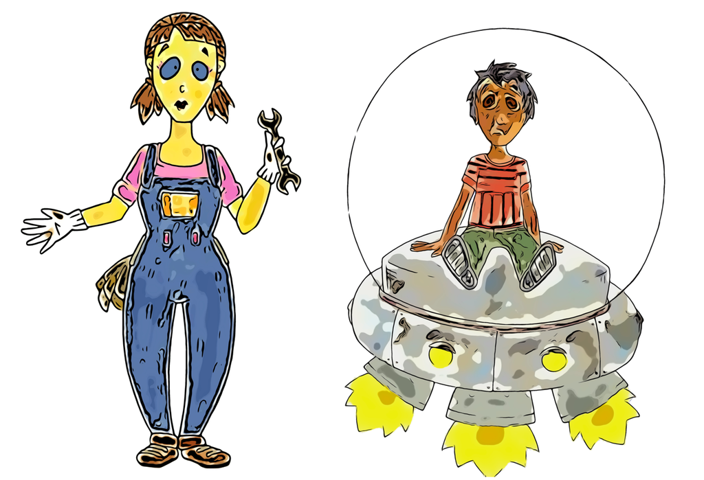

Spielgrafik 3: ‚Emmi‘ und ‚Sertan‘

**Spielgrafik 4:** ‚BenBox‘ und ‚Kleaner‘

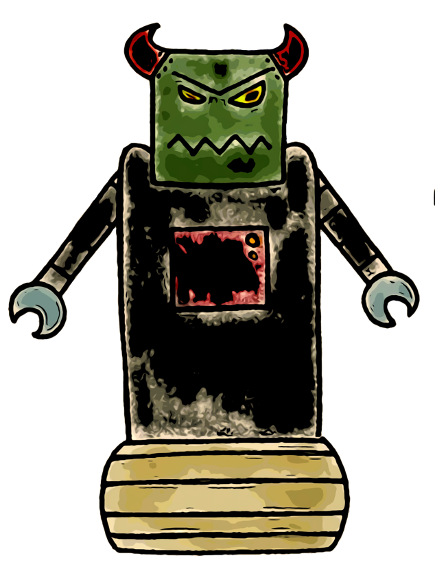

Spielgrafik 4: ‚BenBox‘ und ‚Kleaner‘

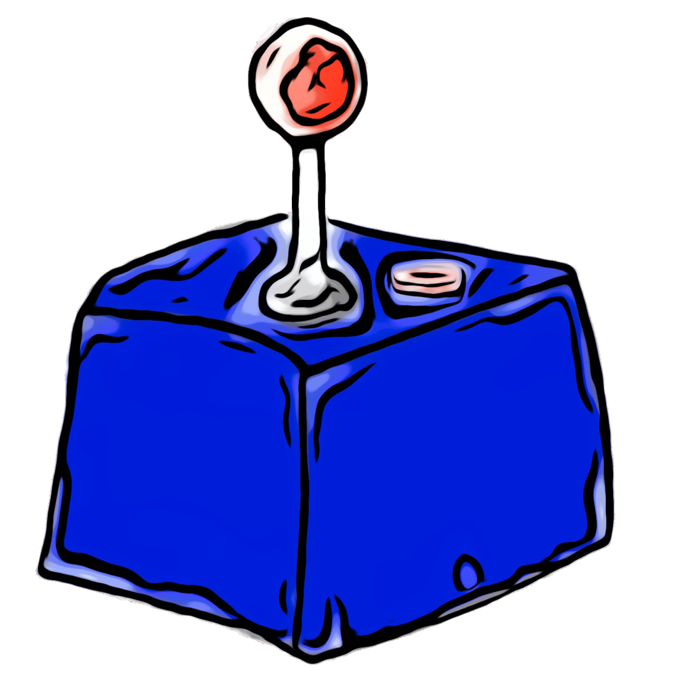

Spielgrafik 4: ‚BenBox‘ und ‚Kleaner‘

**Spielgrafik 5:** ‚Maschinenraum‘

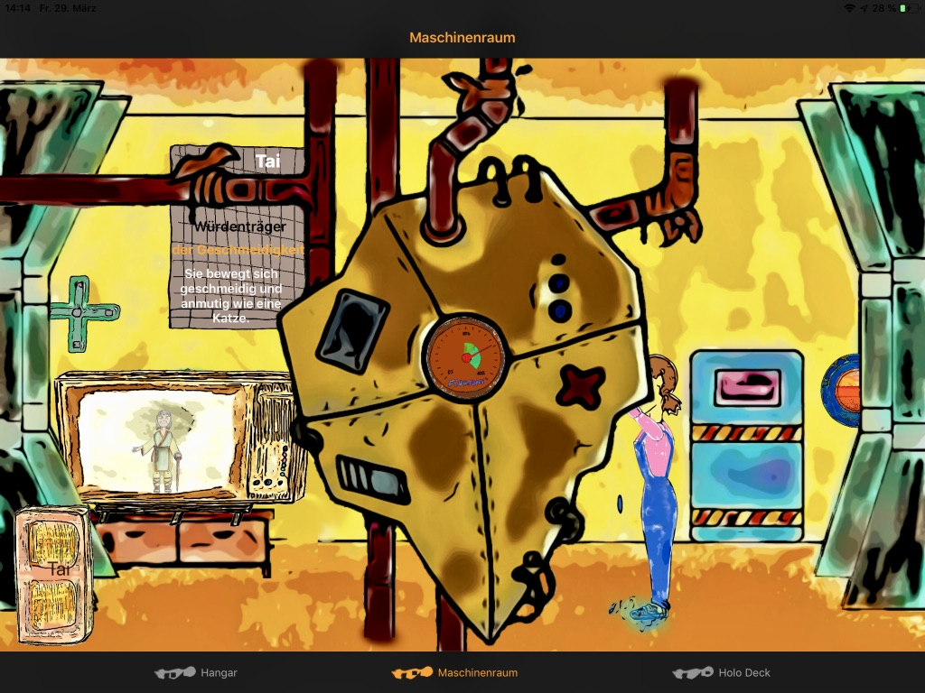

Spielgrafik 5: ‚Maschinenraum‘

**Spielgrafik 6:** ‚Hangar‘

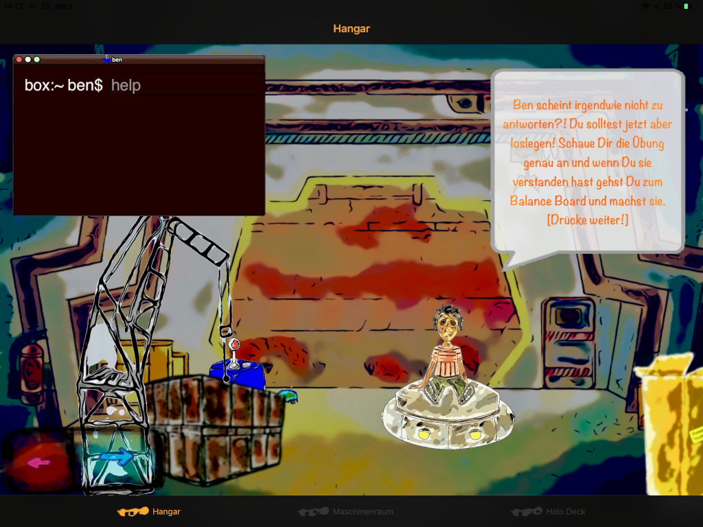

Spielgrafik 6: ‚Hangar‘

**Spielgrafik 7:** ‚Holo Deck‘

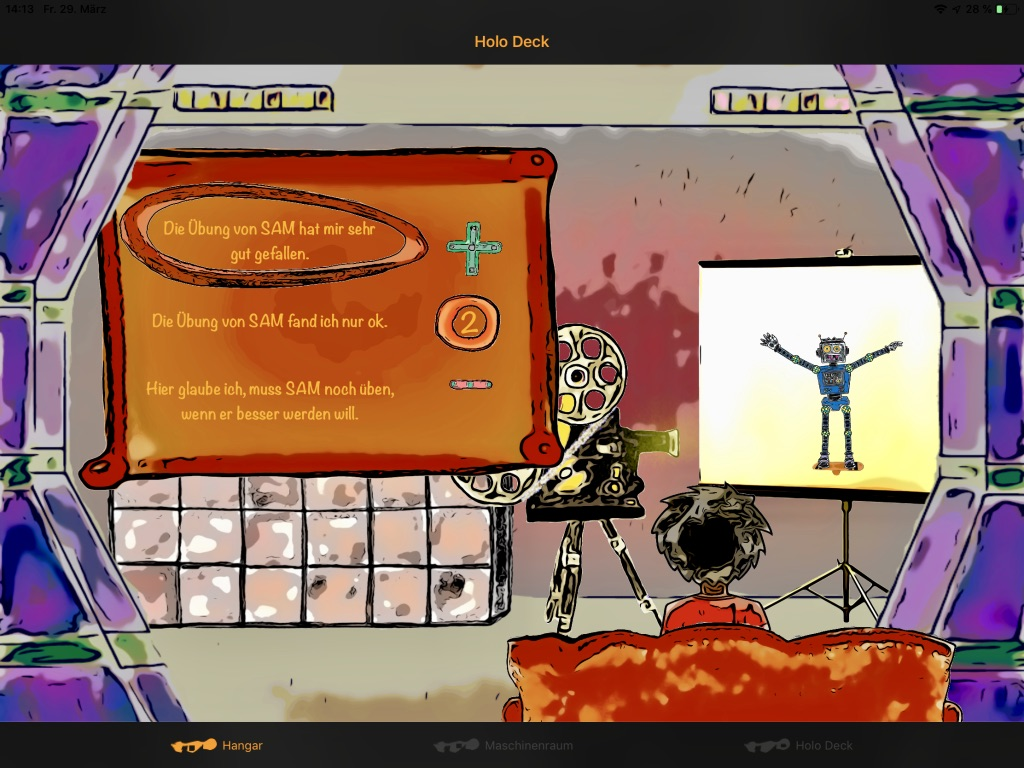

Spielgrafik 7: ‚Holo Deck‘

**Spielgrafik 8:** ‚BenBox Protokolle‘

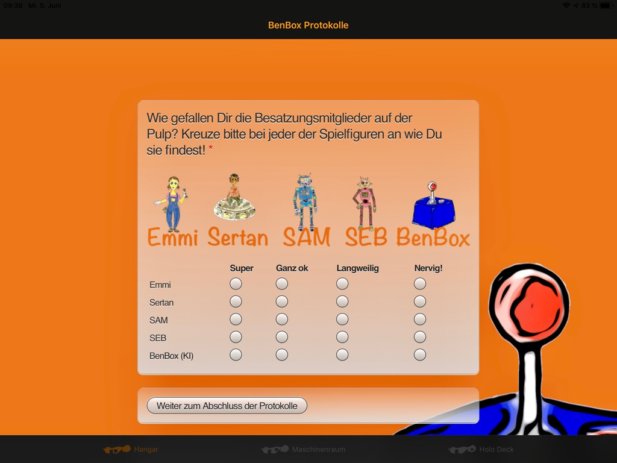

Spielgrafik 8: ‚BenBox Protokolle‘

**Spielgrafik 9:** ‚Via Sacra‘

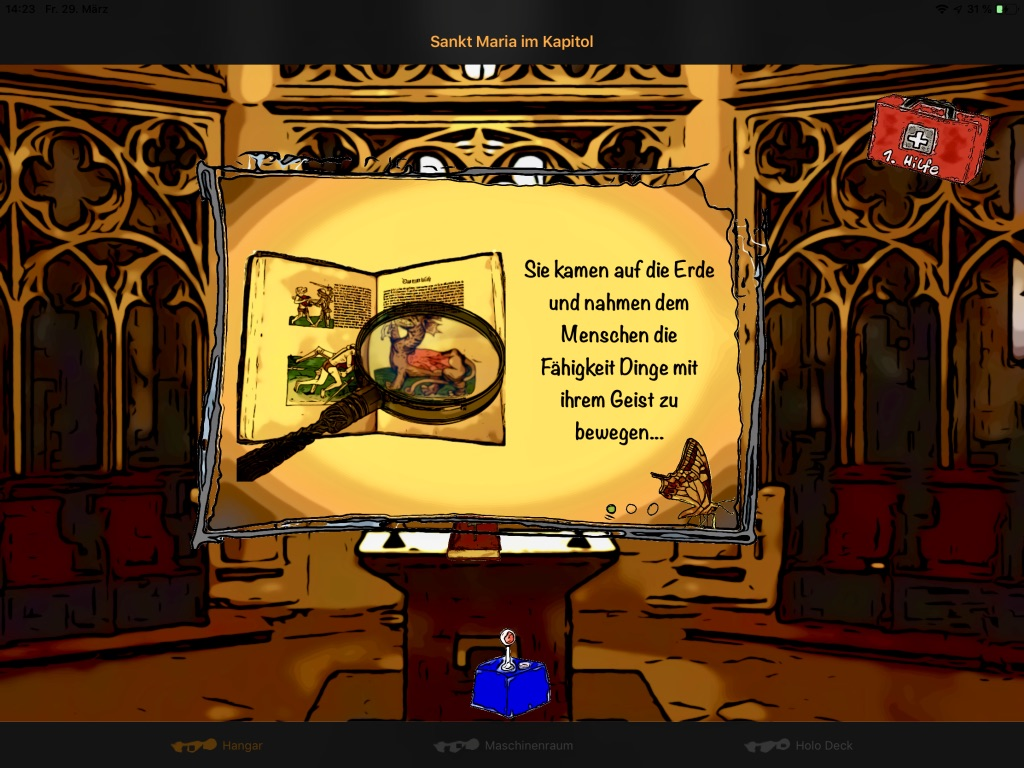

Spielgrafik 9: ‚Via Sacra‘

**Spielgrafik 10:** ‚Updater‘

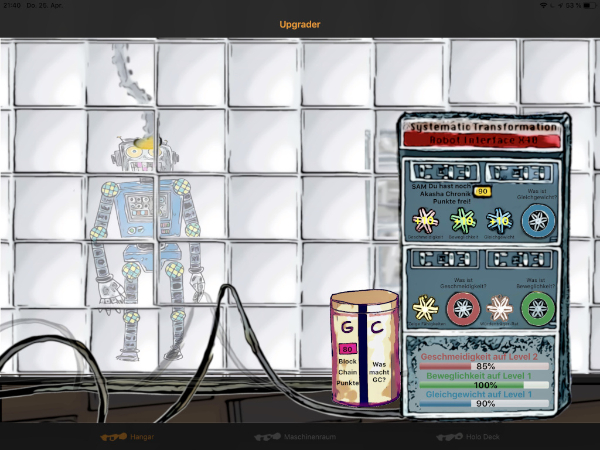

Spielgrafik 10: ‚Updater‘

**Spielkarten:** Auswahl

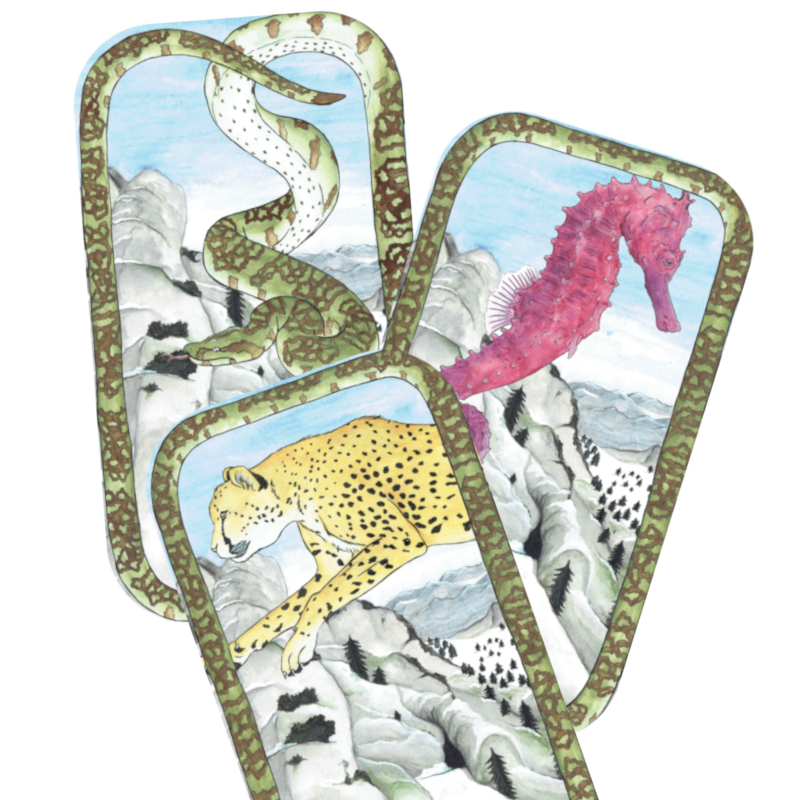

Spielkarten: Auswahl

**Spielgegenstände:** BenBox Balance Board und Kirchenmauer

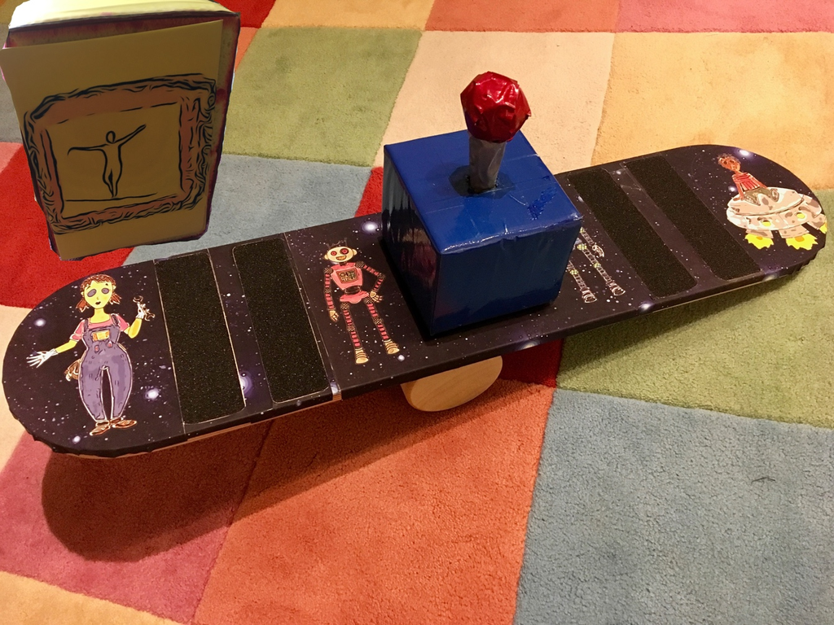

Spielgegenstände: BenBox Balance Board und Kirchenmauer

**Spielgegenstände 2:** Bewertungsregeln

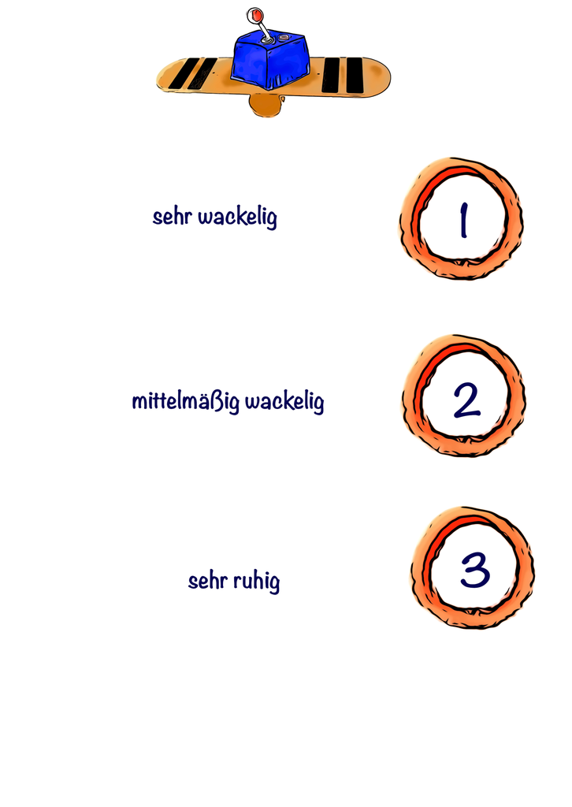

Spielgegenstände 2: Bewertungsregeln

# Eidesstattliche Versicherung

Hiermit versichere ich, dass ich die vorliegende Bachelorarbeit mit dem Titel „BenBox.org Untersuchung eines ‘Serious Game‘ in Bezug auf seinen Nutzen in der Gesundheitsförderung“ selbstständig und ohne fremde Hilfe verfasst habe und keine anderen als die angegebenen Hilfsmittel verwendet wurden.

Die Stellen der Bachelorarbeit, einschließlich der Tabellen und Abbildungen, die anderen Werken dem Wortlaut oder dem Sinn nach entnommen sind, habe ich in jedem Fall kenntlich gemacht und die Herkunft nachgewiesen.

Die Bachelorarbeit hat in gleicher oder ähnlicher Form noch keiner anderen Prüfungsbehörde vorgelegen und wurde auch noch nicht veröffentlicht.

# Literaturverzeichnis

Adler, M., Ganzenberg, E., Martin, M., González, R., & Schubert, N. (2017). *Media activity guide 2017: Mediennutzung im blick*. SevenOne Media GmbH.

Bathge, P. (2019). *Star citizen: Crowdfunding-summe überschreitet 222 millionen US-dollar*. https://www.grin.com/document/212029

Baur, N., & Blasius, J. (2014). *Handbuch methoden der empirischen sozialforschung*. Springer VS.

Becker, L. (2019). *Apples WWDC 2019: iOS 13 mit dunkelmodus, datenschutz und optimierter leistung*. https://www.heise.de/mac-and-i/meldung/Apples-WWDC-2019-iOS-13-mit-Dunkelmodus-Datenschutz-und-optimierter-Leistung-4438243.html

Beineke, J. (2019). *Mobile games: 24 lieblingsspiele der heise-redaktion für smartphone*. https://www.heise.de/ratgeber/Mobile-Games-24-Lieblingsspiele-der-Heise-Redaktionen-fuers-Smartphone-4431033.html

Bensch, M., & Raab-Steiner, E. (2012). *Der fragebogen* (3rd ed.). Facultas Verlag- und Buchhandels AG.

Bourdieu, P. (1983). Ökonomisches kapital, kulturelles kapital, soziales kapital. In R. Kreckel (Ed.), *Soziale ungleichheiten* (pp. 183–199). Schwartz.

Bucher, A. (2014). *Psychologie der spiritualität* (2nd ed.). Beltz Verlag.

Bundesjugendministerium. (2017). *Medienkompetenz stärken*. https://www.bmfsfj.de/bmfsfj/themen/kinder-und-jugend/medienkompetenz/medienkompetenz-staerken/75350

Bundesministerium f"ur Bildung und Forschung. (n.d.). *Digitalisierung in bildung und forschung*. https://www.bmbf.de/de/open-access-das-urheberrecht-muss-der-wissenschaft-dienen-846.html. Weblink: o. J. (no year)

Daun, A. (2012). *Starke kinder – wollen wir die wirklich haben?* Karin Fischer Verlag GmbH.

Egger, L. (2009). *The impact of harry potter on readers of his age*. https://www.grin.com/document/212029

Euro-Informationen. (2019). *Die größten krankenkassen: Versicherte 2019*. https://www.krankenkassen.de/krankenkassen-vergleich/statistik/versicherte/aktuell/

Flothow, A., Kempf, H. D., Kuhnt, U., & Lehmann, G. (Eds.). (2011). *KddR-manual. Neue rückenschule: Professionelle kurskonzeption in theorie und praxis*. Elsevier GmbH.

Förstl, H. (2012). *Theory of mind. Neurobiologie und psychologie sozialen verhaltens* (2nd ed.). Springer.

game - Verband der deutschen Games-Branche. (2017). *Gamer kaufen häufiger zusatzinhalte für free-to-play-spiele und co.* https://www.game.de/gamer-kaufen-haeufiger-zusatzinhalte-fuer-free-to-play-spiele-und-co/

game - Verband der deutschen Games-Branche. (2018). *DEUTSCHER GAMES-FONDS. Modell für eine games-förderung des bundes*. https://www.game.de/wp-content/uploads/2018/04/2018-09-28-Deutscher-Games-Fonds.pdf

Gaschler, K. (2019). Optimierung in rasantem tempo. *Gehirn & Geist*, *5_2019*, 82–83.

Goldin, I., & Kutarna, C. (2016). *Die zweite renaissance: Warum die menschheit vor dem wendepunkt steht*. FinanzBuch Verlag.

Greiner, W., Schulenburg, J.-M. G., & Vauth, C. (Eds.). (2008). *Gesundheitsbetriebslehre*. Verlag Hans Huber.

Gugutzer, R., & Staack, M. (Eds.). (2015). *Körper und ritual. Sozial- und kulturwissenschaftliche zugänge und analysen*. Springer Fachmedien.

Günther, B. (2014). *Apple erhält 30*. https://www.mactechnews.de/news/article/Apple-erhaelt-30-der-Einnahmen-von-Microsoft-Office-fuer-iPad-158076.html

Häckl, D. (2010). *Neue technologien im gesundheitswesen. Rahmenbedingungen und akteure*. Gabler Verlag.

Heim, D. (2018). *Supercell erklärt automatisierte monetarisierung in clash royale*. https://www.newsslash.com/n/12669-supercell-erklaert-automatisierte-monetarisierung-in-clash-royale

Hennings, S. (2012). *Patientenbefragung als chance für qualitätsmanagement und praxismarketing*. Diplomica Verlag GmbH.

Herbig, D. (2019). *Google stadia: Cloud-gaming-dienst kostet 10 euro im abo*. https://www.heise.de/newsticker/meldung/Google-Stadia-Cloud-Gaming-Dienst-kostet-10-Euro-im-Abo-4441177.html

Hollenberg, S. (2016). *Fragebögen. Fundierte konstruktion, sachgerechte anwendung und aussagekräftige auswertung*. Springer Fachmedien.

Holler, A. (2012). Freundschaft ist wichtig: Was kinder meinen aus SpongeBob schwammkopf gelernt zu haben. *TELEVIZION*, *25/2012/2*, 19–22.

Informatik und Gesellschaft. (2009). *Schwache KI und starke KI*. http://www.informatik.uni-oldenburg.de/~iug08/ki/Grundlagen_Starke_KI_vs._Schwache_KI.html

IZI (Internationales Zentralinstitut für das Jugend- und Bildungsfernsehen). (2019). *Grunddaten kinder und medien 2019*. https://www.br-online.de/jugend/izi/deutsch/Grunddaten_Kinder_u_Medien.pdf

Jæger, M. M., & Karlson, K. (2018). Cultural capital and educational inequality: A counterfactual analysis. *Sociological Science*, *5*, 775–795. https://doi.org/10.15195/v5.a33

Kallus, K. W. (2016). *Erstellung von fragebogen* (2nd ed.). CPI-Ebner & Spiegel.

Kelava, A., & Moosbrugger, H. (2012). *Testtheorie und fragebogenkonstruktion* (2nd ed.). Springer.

Krämer, S. (2019). *Die kulturtechnik der verflachung*. https://19.re-publica.com/de/news/rp19-sybille-kraemer

Kroeber-Riel, W., & Esch, F. (2015). *Strategie und technik der werbung. Verhaltens- und neurowissenschaftliche erkenntnisse* (8th ed.). W. Kohlhammer GmbH.

Lammenett, E. (2014). *Praxiswissen online-marketing. Affiliate- und e-mail-marketing, suchmaschinenmarketing, online-werbung, social media, online-PR* (4th ed.). Springer Fachmedien.

Land, K.-H. (2018). *Erde 5.0. Die zukunft provozieren*. FutureVisionPress e.K.

Lay, R. (1995). *Nachkirchliches christentum. Der lebende jesus und die sterbende kirche* (2nd ed.). Ebner.

Legner, A. (1989). *Reliquien. Verehrung und verklärung*. Greven & Bechtold GmbH.

Leven, D., & Knaak, P. (2017). Viel zu verlieren. *Stiftung Warentest*, *7*, 26–31.

Martin-Niedecken, A. L., & Mekler, E. D. (2018). The ExerCube: Participatory design of an immersive fitness game environment. In S. Göbel, A. Garcia-Agundez, T. Tregel, M. Ma, J. Baalsrud Hauge, M. Oliveira, T. Marsh, & P. Caserman (Eds.), *Serious games – 4th joint international conference, JCSG 2018* (pp. 263–275). Springer Nature Switzerland AG.

Mummendey, H. D., & Grau, I. (2014). *Die fragebogenmethode. Grundlagen und anwendung in persoenlichkeits-, einstellungs- und selbstkonzeptforschung*. Hogrefe.

Niebert, F. (2018). *HYBRID-BRETTSPIELE: DIE NEUE GENERATION DES SPIELENS*. https://www.trendyone.de/news/hybrid-brettspiele-die-neue-generation-des-spielens

Nissen, T. (n.d.). *Taschengeldtabelle. Wie hoch sollte das taschengeld sein?* https://www.arbeitsgemeinschaft-finanzen.de/soziales/taschengeld/. Weblink: o. J.

Nvidia. (n.d.). *Deep learning*. https://developer.nvidia.com/deep-learning. Weblink: o. J.

O’Neill, H. M., Maarbjerg, S. J., Crane, J. D., Jeppesen, J., Jørgensen, S. B., Schertzer, J. D., Shyroka, O., Kiens, B., Denderen, B. J. van, Tarnopolsky, M. A., Kemp, B. E., Richter, E. A., & Steinberg, G. R. (2011). AMP-activated protein kinase (AMPK) β1β2 muscle null mice reveal an essential role for AMPK in maintaining mitochondrial content and glucose uptake during exercise. *Proceedings of the National Academy of Sciences*, *108*(38), 16092–16097. https://www.pnas.org/content/108/38/16092

Perridon, L., Steiner, M., & Rathgeber, A. (2016). *Finanzwirtschaft der unternehmung* (17th ed.). Verlag Franz Vahlen.

Porst, R. (2014). *Fragebogen. Ein arbeitsbuch*. Springer VS.

PRNewswire. (2018). *PlayFusion: Sammelkarten-booster packs für "warhammer age of sigmar: Champions" ausverkauft*. https://www.presseportal.de/pm/130009/4036737

Pyka, P. (2017). *MARKETING 4.0. Der leitfaden für das marketing der zukunft*. Campus Verlag.

Russell, S. J., & Norvig, P. (2016). *Artificial intelligence: A modern approach* (3rd ed.). Pearson.

Schellhammer, S. (2002). *Bewegungslehre. Motorisches lernen aus sicht der physiotherapie*. Urban & Fischer Verlag.

Schmitt, F., Christopher, S. M., Tumanov, K., Weiss, G., & Mockel, R. (2018). Evaluating the adoption of the physical board game ludo for automated assessments of cognitive abilities. In S. Göbel, A. Garcia-Agundez, T. Tregel, M. Ma, J. Baalsrud Hauge, M. Oliveira, T. Marsh, & P. Caserman (Eds.), *Serious games – 4th joint international conference, JCSG 2018* (pp. 263–275). Springer Nature Switzerland AG.

Schmitt-Sausen, N. (2018). USA: Das digitalzeitalter entfaltet sein potential. *Deutsches Ärzteblatt*, *115*(15), A-698 / B-600 / C-601.

Schneider, F. (2017). *Entwickler verrät: Werbung bringt deutlich mehr als in-app-kauf zur deaktivierung von werbung*. https://www.appgefahren.de/entwickler-verraet-werbung-bringt-deutlich-mehr-als-in-app-kauf-zur-deaktivierung-von-werbung-191605.html

Scholl, A. (2018). *Die befragung* (4th ed.). UVK Verlagsgesellschaft mbH.

Schön, D. (2013). *Android-app bewerben: Die 5 besten marketing-tipps*. https://praxistipps.chip.de/android-app-bewerben-die-5-besten-marketing-tipps_20262

Sinclair, J., Hingston, P., & Masek, M. (2009). Exergame development using the dual flow model. *Proceedings of the Sixth Australasian Conference on Interactive Entertainment*, 11.

Spitzer, M. (2002). *Lernen. Gehirnforschung und schule des lebens*. Spektrum Akademischer Verlag GmbH.

Steinmüller, W., Schaefer, K., & Fortwängler, M. (2009). *Gesundheit – lernen – kreativität. Alexander-technik, eutonie gerda alexander und feldenkrais als methoden zur gestaltung somatopsychischer lernprozesse* (2nd ed.). Verlag Hans Huber.

Strahringer, S., & Leyh, C. (2017). *Gamification und serious games. Grundlagen, vorgehen und anwendungen*. Springer Fachmedien.

Strotbaum, V., & Reiss, B. (2017). Apps im gesundheitswesen – echter medizinischer nutzen oder der weg zum gläsernen patienten. In Müller-Mielitz & Lux (Eds.), *E-health-ökonomie* (pp. 359–383). Springer Fachmedien.

Techniker Krankenkasse. (2019). *App fördert frühkindliche sprache*. Die Techniker. Das Magazin, 1/19, 28.

Thomas, C. (2018). *Cross platform mobile development in 2018: A beginner’s guide*. https://trifinlabs.com/cross-platform-mobile-development/

Tischer, S. (2018). *Millionen-exit bei freeletics: Gründer steigen aus*. https://www.munich-startup.de/39490/exit-freeletics/

Toman, R. (Ed.). (1996). *Die kunst der romanik*. Neue Stalling.

Urlen, M. (2017). Hellhörig werden, wenn kinder zu sehr fixiert sind. *Stiftung Warentest*, *7*, 32.

Von Reventlow, C., & Thesen, P. (2019). *The digital shift. Design’s new role as artificial intelligence transforms into personal intelligence*. Steidl.